# Staple foods: root crops, bananas, breadfruit and sago

Malcolm Ross

## 1. Introduction

A Proto Oceanic (POc) meal was typically made up of two categories of ingredient, *kanaŋ ‘staple food, starchy food’ (ch.2, §6.1) and *tamaji ‘additional ingredients to accompany starchy food’ (ch.2, §6.2). The main ingredients of *tamaji were - or rather are in today’s Oceanic societies - green vegetables, treated in chapter 10, and coconut cream, treated in §4.2 of chapter 12.

The present chapter treats staple foods. The chapter is divided according to the four categories of staple foods: root crops (§2), bananas (§3), breadfruit (§4) and stem starch, principally sago (§5).

## 2. Root crops

There is no term for root crops in general in most Oceanic languages, and there was apparently no general term in POc. The only major staple root crops known to POc speakers were yams (*Dioscorea* spp., §2.1) and taro (*Colocasia* and Alocasia spp., §2.2).

Of the root crops found in the Pacific today, the widely consumed sweet potato (*Ipomoea batatas*), as well as cassava (*Manihot esculenta*) and American or Chinese/Hong Kong taro (*Xanthosoma sagittifolium*), are relatively recent introductions from South America, brought by Europeans to Indonesia, whence they spread to New Guinea.[^1] They were certainly not present in NW Island Melanesia in POc times. Indeed, the sweet potato arrived in the Bismarck Archipelago and the Solomons only with European traders and settlers in the 19th century (Bourke forthcoming). Barrau (1965) suggests that these introduced crops relegated some less significant earlier staples to the status of famine foods: basing himself on Guppy (1906), he names *Pueraria lobata*, *Dioscorea nummularia* and *Cycas rumphii* as possible earlier staples.

Yams and taro differ in their distributions since yams, and especially *Dioscorea alata*, have more demanding environmental requirements. Unlike *Colocasia* taro, which thrives in generally rainy areas, in damp soil, and up to altitudes of 2200 m or so, yams require seasonal rainfall and flourish in deep, well-drained soils. They are grown in open gardens as they need sunlight. Although *Dioscorea alata* and *Dioscorea esculenta* require a similar environment, *Dioscorea alata* can be grown at altitudes up to 1900 m, *Dioscorea esculenta* only to less than 1000 m (M. Bourke, pers. comm.). Thus Ivens (1927) describes a difference in root crops among speakers of dialects of South Malaitan. On the island of Ulawa, only *Dioscorea alata* was cultivated. On Small Malaita *Dioscorea esculenta* was also grown on the low hills. On Malaita proper, people lived on the central ridge at 1000 m and had no yams, only taro.

Because of its environmental tolerance the taro tuber *Colocasia esculenta* is the most important subsistence plant in Melanesia (Barrau 1955: 50). When the ancestors of POc speakers arrived in the region *Colocasia esculenta* was already the dominant staple over much of New Guinea. In drier lowland and mid-altitude areas *Dioscorea* species predominated (Bourke 1982, Swadling & Hide 2005). However, it seems likely on circumstantial grounds that the yam *Dioscorea alata* was an important staple of POc speakers, at least immediately after their arrival in the Bismarcks.

POc speakers lived on small islands and in coastal enclaves (vo1.2, ch.2), and most of their environments were probably suitable for growing *Dioscorea alata*. Taro would have assumed greater importance as they moved inland on the larger islands. Significantly, one of the POc terms for *Colocasia* taro was *mʷapo(q), a borrowing from a mainland Papuan language (§2.2.1). Taro was certainly known to POc speakers - they also had their own Austronesian word for it, *talo(s) - but the presence of a Papuan borrowing for such a seemingly central item of diet implies that taro cultivation came to assume greater importance through contact with taro growers on the New Guinea mainland.

Both yams and taro allow some variety in their preparation for eating: they are boiled, braised or baked whole or in large chunks, and sometimes they are eaten grated or mashed.

A huge number of varieties of both yams and *Colocasia* taro (in the tens, if not the hundreds) are individually named in Oceanic-speaking communities (Malinowski 1935a: 100–104, Fox 1978, Barrau 1962: 99-100). Where more than one name for a species is reconstructed, it may be that one or other name denoted a variety. However, no deliberate attempt has been made here to reconstruct names for varieties, partly because sources do not provide Linnaean names for individual varieties and partly because their names are often transparently descriptive and have probably been innovated over and over again.

### 2.1. Yams, *Dioscorea* spp.

Unlike the Araceae (taros and taro-like plants; §2.2) with their large leaves, yam plants form long vines which in the wild twine around tree trunks. When they are cultivated, the farmer usually provides a stake or frame for support. On Ulawa yams were planted communally only in newly cleared gardens.[^2] The men felled the trees, cleared the ground and dug the holes, and the women planted the small tubers or tuber tops or slices (Ivens 1927: 10, 355-357). In other places yams are sometimes planted in old gardens, but only after they have lain fallow for a while, as yams need fertile soil. Generally there is only one yam crop per year, and tubers are harvested 9-12 months after planting. However, on Small Malaita and Ulawa yam tops were also planted as yams were consumed, providing an earlier occasional crop (Ivens 1927: 361).

Barrau (1955: 39–40) points out that yam-growing communities require a good understanding of the seasons. ‘Flowering and fructification of local plants often indicate to the natives the season best suited for the various agricultural activities.’ Thus on Espiritu Santo (Vanuatu) and in Fiji, yams are planted when the coral trees, *Erythrina variegata* (ch.5, §5.5), are in flower (Baker & Harrison 1936).

Preparing and planting a yam garden requires a major effort, and in many yam-growing communities the planting was associated with rituals and incantations calling on the spirits to stand guard over the crop, protecting it from thieves, yam beetles and other malign beings (Fox 1924: 104-106, Malinowski 1935a). On Ulawa the rituals began the night before planting by blessing the pieces of yam to be planted, followed in the morning by incantations in the garden and culminating with a small feast (Ivens 1927: 358-361). Weeding also had associated ritual. The women bathed, and then ceremonially cleansed themselves with *Euodia* sprigs (ch.7, §5.6) before they went to weed the yam garden. When the yams were ready for harvesting, the priest took to the beach two yams tied with *Dracaena* (ch.13, §6.1), where he sacrificed them to the sea spirits on behalf of the village. Only after this might the villagers harvest their yams as they needed them (Ivens 1927: 362-363). On both Small Malaita and Ulawa the yams were first placed in a temporary shelter near the garden, then transferred to a storehouse (Ivens 1927: 363-366). Malinowski’s (1935) account of yam cultivation among the Kilivila is similar to Ivens’ account of the Ulawa; the processes are the same, the rituals pervasive, but yam cultivation is strictly a male domain.

Because they are seasonal, communities dependent on fresh yams alone would undergo regular food shortages while the young yams were growing (Barrau 1955: 58). Before the advent of the sweet potato a few hundred years ago, the perils of shortage were avoided in two ways. First, yams were often co-staples with other starchy foods: in New Guinea societies with either *Colocasia* taro or bananas (Bourke 1982), in Vanuatu coastal communities with breadfruit (Walter & Sam 2002: 41). Secondly, by storage: of the root crops grown in NW Island Melanesia, yams can be stored longest, kept on shaded or dark shelves in a dry, well aired location for up to six months, providing food between harvest periods (Henderson & Hancock 1988: 19). Yam storage houses are a salient feature in Melanesian villages from the Trobriand Islands of Papua New Guinea to New Caledonia (Barrau 1955: 58).

#### 2.1.1. Why so few yam terms?

Today six yam species are found in Melanesia: *Dioscorea alata*, *Dioscorea bulbifera*, *Dioscorea esculenta*, *Dioscorea pentaphylla*, *Dioscorea hispida*, and *Dioscorea nummularia* (Barrau 1955: 56, Bourke 1982). The first four are present throughout the region, but POc names can be reconstructed for only the first two. This is curious, because the two main garden yam species in NW Island Melanesia today are the greater yam, *Dioscorea alata*, and the lesser yam, *Dioscorea esculenta*. We might expect to reconstruct a POc term for at least the first four species, and certainly for *Dioscorea esculenta*, but no term for the latter can be reconstructed with certainty. Barrau (1965) suggests that *Dioscorea nummularia*, which he found cultivated in scattered locations throughout the Pacific,[^3] was also once much more widely cultivated than it is today. No term can be reconstructed for it, but this is likely to be an artifact of the data: no source offers a term for it.

The lesser yam is agronomically superior to the greater yam and is in many areas a major source of nutrition, but it is the greater yam which is ceremonially significant and a source of prestige for the grower (Bourke 1982:55, in preparation and pers. comm.).[^4] From this one may infer that the greater yam is an ancient crop, whilst the lesser yam was cultivated at least a little more recently - but long pre-dates the sweet potato.

The linguistic evidence is consistent with Bourke’s inference. The POc etymon *qupi ‘greater yam, *Dioscorea alata*’ indicates that POc speakers had this crop, and the fact that it was also the generic term for yams suggests that it was the ‘default’ yam species in the POc economy. Because there is no widely distributed cognate set, no POc term for the lesser yam, *Dioscorea esculenta*, can be reconstructed. What does this imply? In its wild state the lesser yam seems to have long been a feature of the forests of NW Island Melanesia and was presumably present in the POc period.[^5] The most appropriate conclusion seems to be that when POc was breaking up it had not yet been extensively cultivated, and that it became a significant part of the diet only as early Oceanic speakers moved inland on the larger islands from their coastal and small-island habitats.

By the same token, the apparent existence of a POc term for *Dioscorea bulbifera*, the potato yam, implies that it was consumed by POc speakers, even though it is today cultivated only as a marginal crop and only in certain parts of New Guinea.

The visible differences between *Dioscorea alata*, *Dioscorea esculenta* and *Dioscorea bulbifera* are shown in Figure 9.1.

#### 2.1.2. *Dioscorea alata*, greater yam, water yam, winged yam, TP *yam*, P *iam* (Dioscoreaceae)

Left to themselves, *Dioscorea alata* tubers come in an amazing variety of forms, as shown in Figure 9.2. In various parts of Oceanic-speaking Melanesia - the Papuan Tip islands, Fiji, New Caledonia - farmers strove to produce yams with a regular form and giant length. Barrau (1955: 57) mentions a 2.6 m yam seen in New Caledonia in 1953. These long yams were produced by hollowing out a cylindrical growing hole and lining it with wooden sticks to provide growth space for the tuber. More generally, the yield is maximised by staking the growing vine with a support 2-3m high.

It is not nutrition that drives the desire to produce the largest and the most yams in Melanesian societies, but rather competition for prestige, carried out by exhibiting one’s success as a yam grower. Thus among Kilivila speakers of the Trobriands yams are displayed first in conical heaps in the garden, then again in front of the in-law’s storehouse, before being placed in one’s own storehouse. A good feast, from the host’s perspective, is one at which the guests eat their fill of yam, then see how full their host’s storehouse remains after the feast. A large yam with a fantastic form is good for display. The very fact that yams can be stored places them above taro in the food hierarchy because it allows a man to accumulate them until he can distribute them at a feast in the large quantities which bolster his prestige (Howes 2003: 67-68, 96-97).

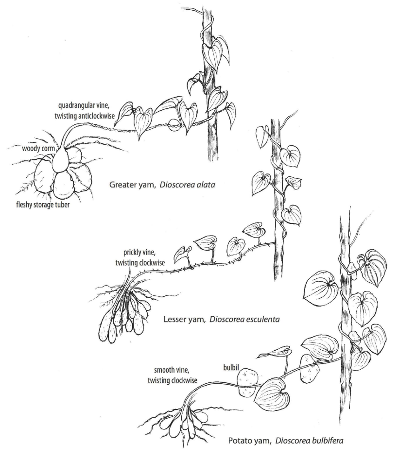

**Figure 9.1:** Growth habit of three yam (*Dioscorea*) species

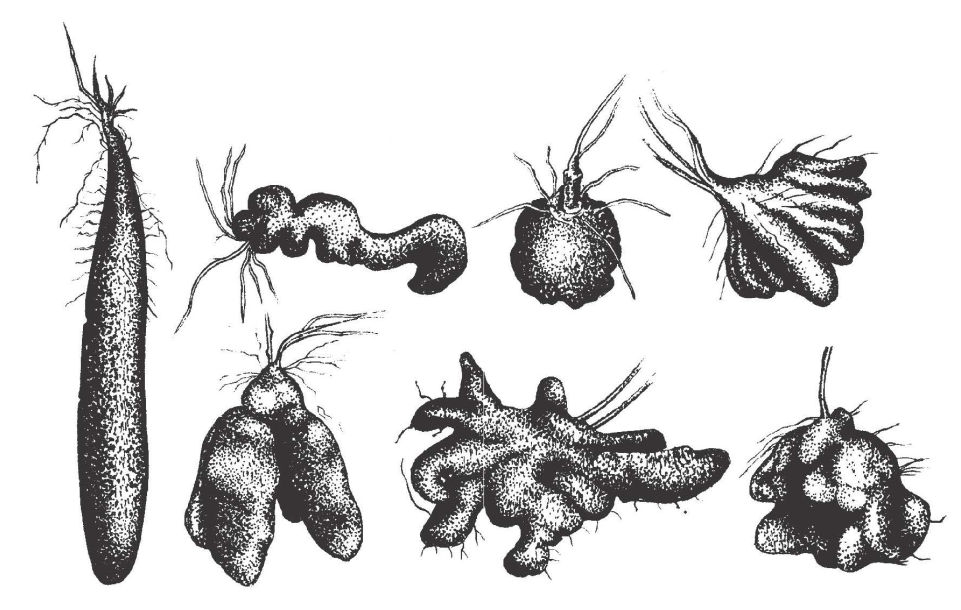

**Figure 9.2:** Yam (*Dioscorea alata*) tuber shapes

The most widely reflected term for *Dioscorea alata* is POc *qupi, which is also widely reflected in a second sense as the generic term for yams.

| **PMP** |  | *qubi | ‘yam’ (Dempwolff 1938) |
| --- | --- | --- | --- |
| **POc** |  | *qupi | ‘greater yam, *Dioscorea alata*; yam (generic)’ |
| Adm | Drehet | *u* | ‘greater yam; yam (generic)’ |
| NNG | Malasanga | *kui-kui* | ‘greater yam; yam (generic)’ |
| PT | Iduna | *kuvi* | ‘greater yam; yam (generic)’ |
| MM | Vitu | *ɣuvi* | ‘greater yam; yam (generic)’ |
| MM | Tolai | *a-up* | ‘greater yam; yam (generic)’ |
| MM | Marovo | *uvi* | ‘greater yam; yam (generic)’ |
| MM | Maringe | *n-ufi* | ‘greater yam, *Dioscorea alata*; yam (generic)’ (Henderson and Hancock 1988) |
| TM | Buma | *uwâ* | ‘yam’ |
| TM | Tanema | *uva* | ‘yam’ |
| TM | Tanibili | *no-upio* | ‘yam’ |
| TM | Vano | *upie* | ‘yam’ |
| SES | Lengo | *uvi* | ‘greater yam, *Dioscorea alata*; yam (generic)’ (Henderson and Hancock 1988) |
| SES | Arosi | *uhi* | ‘greater yam; yam (generic)’ |
| NCV | Uripiv | *n-ov* | ‘k.o. yam’ |
| NCV | Paamese | *o-uhu* | ‘greater yam; yam (generic)’ |
| NCV | Lewo | *yuwi* | ‘greater yam; yam (generic)’ |
| NCV | Namakir | *ʔuw* | ‘greater yam; yam (generic)’ |
| NCV | Nguna | *na-wii* | ‘greater yam; yam (generic)’ |
| NCV | Lewo | *yui* | ‘yam (generic)’ |
| SV | Sye | *n-up* | ‘greater yam; yam (generic)’ |
| SV | North Tanna | *n-up* | ‘greater yam; yam (generic)’ |
| SV | Kwamera | *n-uk* | ‘greater yam; yam (generic)’ |
| SV | Southwest Tanna | *n-ekw* | ‘greater yam; yam (generic)’ |
| SV | Lenakel | *n-uw* | ‘greater yam; yam (generic)’ |
| SV | Whitesands | *n-u* | ‘greater yam; yam (generic)’ |
| SV | Anejom̃ | *n-u* | ‘greater yam; yam (generic)’ |
| NCal | Pije | *kuuk* | ‘greater yam; yam (generic)’ |
| NCal | Fwai | *kuuk* | ‘greater yam; yam (generic)’ |
| NCal | Nemi | *kuuk* | ‘greater yam; yam (generic)’ |
| NCal | Jawe | *kuic* | ‘greater yam; yam (generic)’ |
| NCal | Nyelâyu | *uvi* | ‘greater yam; yam (generic)’ |
| NCal | Nêlêmwâ | *kuvic* | ‘greater yam; yam (generic)’ |
| NCal | Xârâcùù | *ku* | ‘greater yam; yam (generic)’ |
| NCal | Iaai | *u* | ‘greater yam; yam (generic)’ |
| Fij | Wayan | *uvi* | ‘greater yam; yam (generic)’ |
| Pn | Tongan | *ʔufi* | ‘greater yam; yam (generic)’ |
| Pn | Samoan | *uji* | ‘greater yam; yam (generic)’ |

Three other terms can be reconstructed from cognate sets some of whose members are glossed ‘large yam’, ‘greater yam’ or ‘*Dioscorea alata*’. This is weak evidence for inferring that the reconstructed terms denoted a *Dioscorea alata* cultivar. The terms are POc *mʷaruqe, POc *udu(r,R) and POc *pʷasepe.

| **POc** |  | *mʷaruqe | ‘*Dioscorea* sp. or perhaps a cultivar of *Dioscorea alata*’ |
| --- | --- | --- | --- |
| Adm | Titan | *mʷare(n)* | ‘a big yam’ |
| Adm | Loniu | *mʷat* | ‘k.o. large yam’ |
| MM | Roviana | *marihi* | ‘yam’ (borrowed?) (Henderson and Hancock 1988) |
| NCV | Paamese | *a-marue* | ‘k.o. wild yam’ |
| NCV | Lewo | *mol-malu* | ‘k.o. wild yam, ready before cultivated yams’ |
| NCV | Nguna | *mʷālu* | ‘k.o. yam like English potato’ |
| NCV | Namakir | *māroʔ* | ‘k.o. taro’ |
| NCV | South Efate | *n-mʷal* | ‘*Dioscorea* sp.’ |
| **PSV** |  | *-mʷariq | ‘*Dioscorea* sp.’ (Lynch 2001c: 234) |
| SV | Sye | *(n-uv)mori* | ‘*Dioscorea* sp.’ (*n-uv* ‘yam (generic)’) |
| SV | Ura | *(n-up)mori* | ‘*Dioscorea* sp.’ (*n-up* ‘yam (generic)’) |

| **POc** |  | *udu(r,R) | ‘*Dioscorea alata* cultivar (?)’ |
| --- | --- | --- | --- |
| NNG | Amara | *(o)udo* | ‘greater yam’ |
| MM | Kara (West) | *udi* | ‘greater yam’ |
| MM | Nalik | *udur* | ‘greater yam’ |
| SES | Arosi | *ugu-ugu* | ‘yam sp. with nice smell’ |

POc *pʷasepe ‘*Dioscorea alata* variety(?)’ is of interest, because it also seems to be the source of the PT forms listed below the cognate set. However, the sound correspondences attested by the PT forms are not those of PT languages but the distinctive reflexes (*pʷ > *kʷ*; *s > *t*) of North Malaitan languages of the SES group. Dictionaries are available for two North Malaitan languages, Lau (Fox 1974) and Kwaio (Keesing 1975), but neither includes this item. I assume it is nonetheless a borrowing from a North Malaitan language, but I do not know the source of the borrowing.

| **POc** |  | *pʷasepe | ‘*Dioscorea alata* variety(?)’ |
| --- | --- | --- | --- |
| MM | Petats | *waseh* | ‘*Dioscorea alata*’ |
| MM | Selau | *wesewe* | ‘*Dioscorea alata*’ |

cf. also:

| PT | Molima | *atea* | ‘greater yam’ |
| --- | --- | --- | --- |
| PT | Dobu | *kʷatea* | ‘yam’ |
| PT | Duau | *kʷatea* | ‘yam’; ‘lesser yam’ |
| PT | ’Auhelawa | *ateya* | ‘yam’ |
| PT | Sariba | *kʷatea* | ‘greater yam, *Dioscorea alata*; yam (generic)’ |
| PT | Tubetube | *kʷatea* | ‘greater yam’ |

#### 2.1.3. *Dioscorea bulbifera*, potato yam, aerial yam, air potato (Dioscoreaceae)

The terms ‘potato yam’ and ‘aerial yam’ reflect the fact that *Dioscorea bulbifera* has multiple aerial bulbils rather than a single basal tuber. Except in parts of Papua New Guinea it is not cultivated but quite commonly grows wild (Barrau 1962: 113). Its bulbils contain a toxin, dioscorine, and need to be cooked and grated, then washed continuously in fresh water for several hours (Barrau 1955: 59). In Papua New Guinea it is sometimes cultivated as a minor staple alongside the two major staple species, *Dioscorea alata* and *Dioscorea esculenta* (Bourke 1982).

POc *pʷatika evidently referred to the potato yam, *Dioscorea bulbifera*, because its reflexes denote this species in widely separated languages: Patpatar (MM), Kwara’ae (SES) and Sye and Ura (SV) (the Chuukese form appears to be borrowed). The languages in which it is glossed ‘lesser yam’ (*Dioscorea esculenta*) are contiguous and appear to represent a semantic innovation local to central New Ireland.

| **POc** |  | *pʷatika | ‘potato yam, aerial yam, *Dioscorea bulbifera*’ |
| --- | --- | --- | --- |
| Adm | Lou | *puet* | ‘*Dioscorea bulbifera*’ |
| PT | Boanaki | *posika* | ‘yam’ |
| MM | Notsi | *pias* | ‘lesser yam’ |
| MM | Tabar | *poti-poti* | ‘lesser yam’ |
| MM | Lamasong | *patik* | ‘lesser yam’ |
| MM | Patpatar | *patuk* | ‘*Dioscorea bulbifera*’ |
| MM | Halia | *pat* | ‘greater yam’ |
| SES | Kwara’ae | *(dau)fasia* | ‘*Dioscorea bulbifera* cultivars’ (Henderson and Hancock 1988) |
| **PSV** |  | *(nə-tai-)bʷatɣV | ‘yam sp.’ (Lynch 2001c) |
| SV | Sye | *(tai)potɣo(nei)* | ‘k.o. wild yam’ |
| SV | Ura | *(dai)borɣe(ni)* | ‘*Dioscorea bulbifera*’ |

cf. also:

| Mic | Trukese | *pʷereka* | ‘*Dioscorea bulbifera*’ (*-r-* for †∅) |
| --- | --- | --- | --- |

#### 2.1.4. *Dioscorea esculenta*, lesser yam, prickly yam, TP *mami*, P *pana* (Dioscoreaceae)

*Dioscorea esculenta* has a prickly vine stem and winds clockwise around its stake, whereas *Dioscorea alata* winds anti-clockwise (Figure 9.1).

The reasons why a POc etymon for this widespread species is apparently not reconstructable are discussed in §2.1.1. There are, however, a number of terms in NNG and MM languages which imply that there may have been a PWOc term for the species.[^6] Two forms are quite widely reflected, *ka-misa and *ma-misa. The *ka-/*ma- alternation is typical of stative (adjective-like) verbs in POc,[^7] implying that this was originally an epithet applied to *Dioscorea esculenta* rather than a noun. However, no other meaning for this word can be reconstructed at present.

The possibility of reconstructing PWOc *ka-misa/*ma-misa ‘lesser yam, *Dioscorea esculenta*’ perhaps means that the lesser yam was domesticated in NW Island Melanesia after the break-up of POc but before PWOc had dispersed far. Against this inference, however, is the fact that we would also expect to find reflexes of such a significant item in languages of the Papuan Tip linkage, the third member linkage of Western Oceanic, yet none have been found.[^8] The S Efate and Wayan Fijian forms are both very doubtful cognates.

| **PWOc** |  | *kamisa | ‘lesser yam, *Dioscorea esculenta*’ |
| --- | --- | --- | --- |
| NNG | Tuam | *amez* | ‘yam’ |
| NNG | Tami | *kamit* | ‘yam’ |
| NNG | Yabem | *ame* | ‘lesser yam, *Dioscorea esculenta*’ |
| NNG | Yalu | *amis* | ‘lesser yam, *Dioscorea esculenta*’ |
| NNG | Sissano | *emiei* | ‘greater yam’ |
| MM | Tangga | *kam* | ‘sweet potato; lesser yam’ |
| MM | Tomoip | *misa* | ‘lesser yam, *Dioscorea esculenta*’ |

cf. also:

| NCV | South Efate | *n-am* | ‘wild varieties of *Dioscorea bulbifera*’ |
| --- | --- | --- | --- |

| **PWOc** |  | *mamisa | ‘lesser yam, *Dioscorea esculenta*’ |
| --- | --- | --- | --- |
| NNG | Poeng | *mamisa* | ‘lesser yam, *Dioscorea esculenta*’ |
| NNG | Mamusi | *mamisa* | ‘yam’ |
| MM | Minigir | *mamisa* | ‘lesser yam’ |

cf. also:

| Fij | Wayan | *mami* | ‘cooking banana with short thick fruit; sweet-tasting, but skin remains green and flesh hard even when ripe’ |
| --- | --- | --- | --- |

#### 2.1.5. Other terms for yam

Further terms for yam can be reconstructed, but it is unclear which species they denoted.

| **PWOc** |  | *gobu | ‘*Dioscorea* sp.’ |
| --- | --- | --- | --- |
| NNG | Numbami | *go-gobu* | ‘greater yam’ |
| NNG | Patep | *ɣɛb* | ‘yam’ |
| MM | Bali | *gobu* | ‘yam, *Dioscorea alata*, cultivar’ (Hide 1985) |
| MM | Kara (East) | *go-gof* | ‘*Dioscorea bulbifera*’ |

| **PROc** |  | *damu | ‘*Dioscorea* sp.’ |
| --- | --- | --- | --- |
| NCV | Mota | *nam* | ‘yam’ |
| NCV | Araki | *tsam* | ‘*Dioscorea* sp.’ |
| NCV | Tamambo | *dam* | ‘yam’ |
| NCV | Ambae | *damu* | ‘*Dioscorea* sp.’ |
| NCV | Raga | *damu* | ‘yam’ |
| NCV | Uripiv | *drum* | ‘*Dioscorea* sp.’ |
| NCV | Naman | *ne-dum* | ‘*Dioscorea* sp.’ |
| NCV | Neve’ei | *ne-dam* | ‘*Dioscorea* sp.’ |
| NCV | Avava | *a-dam* | ‘*Dioscorea* sp.’ |
| NCV | Larëvat | *dram* | ‘*Dioscorea* sp.’ |
| NCV | Nese | *na-ram* | ‘*Dioscorea* sp.’ |
| NCV | Port Sandwich | *na-ⁿram* | ‘yam’ |
| NCV | Lonwolwol | *dɛm* | ‘yam’ |
| SV | Kwamera | *nau-ram* | ‘kind of wild yam’ |
| SV | Anejom̃ | *rame* | ‘k.o. yam, stringy’ |
| NCal | Pije | *dimʷa* | ‘*Dioscorea bulbifera*’ |
| NCal | Jawe | *dimʷa* | ‘*Dioscorea bulbifera*’ |
| NCal | Fwai | *niwâ* | ‘*Dioscorea bulbifera*’ |
| NCal | Nemi | *niwâ* | ‘*Dioscorea bulbifera*’ |
| NCal | Nyelâyu | *demʷa* | ‘*Dioscorea bulbifera*’ |
| NCal | Nêlêmwâ | *demʷa* | ‘*Dioscorea bulbifera*’ |

cf. also:

| Fij | Wayan | *damu(ni)* | ‘k.o. yam with curved tuber and chocolate coloured skin’ (final *-ni* is unexplained) |
| --- | --- | --- | --- |

| **PWOc** |  | *ka(p)ul | ‘seed yam’ |
| --- | --- | --- | --- |
| PT | Dobu | *awona* | ‘seed yam’ |
| PT | Kakabai | *ko-koya* | ‘yam’ |
| PT | Misima | *ka-kaun* | ‘seed yam’ |
| PT | Kilivila | *kaula* | ‘yam’ |
| MM | Tiang | *ko* | ‘lesser yam’ |
| MM | Kara (East) | *ko-kau* | ‘lesser yam, *Dioscorea esculenta*’ |
| MM | Patpatar | *kau-kau* | ‘lesser yam, *Dioscorea esculenta*’[^9] |
| MM | Nehan | *ko-ko* | ‘yam’ |
| MM | Marovo | *co-core* | ‘wild yam sp.’ |

### 2.2. Taro (Araceae)

Most major food plant terms both in English and in Oceanic languages refer to a single genus. The English term ‘taro’ is an exception. In much of the Pacific ‘taro’ is used to refer collectively to five genera of the Araceae family, namely *Colocasia*, *Cyrtosperma*, *Alocasia*, *Amorphophallus*, and *Xanthosoma*, each represented by a single cultivated species in the Pacific and shown in Figure 9.3. The most important species are - and in POc times probably were - *Colocasia esculenta* and *Cyrtosperma merkusii*.

#### 2.2.1. *Colocasia esculenta* (syn. *Colocasia antiquorum*), taro, Asian taro, TP *taro tru* (Araceae)

Like the other Araceae, in its natural state *Colocasia* taro prefers a shady, damp (and even swampy) environment, which explains its cultivation in rain forest environments and the need for irrigation elsewhere. It is often grown on crudely terraced slopes, the terraces supported by tree trunks or stick fences. It is usually propagated by planting a section from the top of the tuber together with the plant’s stem (the leaves are removed). Less often a cutting or a sucker from the side of the corm is used. Ivens (1927: 355) reports from Ulawa that, because taro is not a seasonal crop, the farmer may simply cut the top off a newly pulled tuber and re-plant it immediately. Tubers are ready for harvesting 7-12 months after planting. It grows throughout the year, obviating the need for storage (Barrau 1955: 50-52).

Two POc terms for *Colocasia esculenta* can be reconstructed: *talo(s) and *mʷapo(q). This synonymy perhaps reflects the complex history of taro cultivation by early Oceanic speakers. On the one hand they brought with them varieties of taro that they named *talo(s). Evidence for this is that the term was inherited from PMP. On the other hand they interacted with Papuan speakers in NW Melanesia and may have acquired new taro varieties from them, along with the label *mʷapo(q), which apparently entered POc from a mainland Papuan language. Reflexes of a possible source occur in languages of the northern Adelbert Range in the present-day Madang Province (see Z’Graggen 1980), and the widespread currency in Papuan languages of words with a form resembling *mao* is noted by Dutton (1973: 443) and Hays (2005: 642).

The cognate set from which POc *mʷapo(q) is reconstructed contains several formal difficulties. The alternation of reflexes of POc *m and *mʷ in certain items including this one has been discussed by Blust (1981a). French-Wright (1983: 130–132) also considers the alternation between zero and reflexes of POc *-p- in this set, choosing to reconstruct two POc forms, one with and one without *-p-, but suspecting that they are reflexes of a single form. With more data at our disposal, it is clear on both formal and semantic grounds that this is a single cognate set, but one in which two common sporadic changes often occur, namely that *mʷ becomes *m and that *p is lost between vowels when one is rounded. Some of the NNG reflexes (Kove, Gitua and Mangap) complicate the picture by reflecting POc *-q. These variations may mean that the earliest forms in Oceanic do not date back to POc itself but represent slightly later borrowings from dialect to dialect among early Oceanic dialects.

The distribution of the two cognate sets is also interesting. Whilst POc *mʷapo(q) is distributed throughout Oceania, POc *talo(s) hardly occurs in Western Oceanic. Its only known Western Oceanic reflexes are in Manam (NNG), Motu (PT) and Roviana and Marovo (MM). In the cases of Manam and Motu, no reflex has been found in nearby closely related languages, and it is quite possible that these are borrowings from an Eastern Oceanic language or from an English-based pidgin.[^10] In any case, POc *talo(s) has been widely replaced by POc *mʷapo(q) in Western Oceanic languages. John Lynch (pers. comm.) points out that reflexes of *talo(s) have been replaced by reflexes of PSOc *bʷeta in all of North/Central Vanuatu except South Efate (which arguably subgroups with South Vanuatu).

A search for languages in which reflexes of *talo(s) and *mʷapo(q) are in contrast has turned up very little, but this may be an artefact of inadequate data. Only Arosi reflects both terms, each as the first element of names of taro varieties (see below).[^11] The Arosi generic term for taro is *bʷa*, reflecting neither POc term.

| **PMP** |  | *tales | ‘taro, *Colocasia esculenta*’ (Dempwolff 1938) |
| --- | --- | --- | --- |
| **POc** |  | *talo(s) | ‘taro, *Colocasia esculenta*’ (Capell 1943: *dalo(s)) |
| NNG | Manam | *taro* | ‘taro, *Colocasia esculenta*’ |
| PT | Motu | *talo* | ‘taro, *Colocasia esculenta*’ |
| MM | Roviana | *talo* | ‘taro, *Colocasia esculenta*’ |
| MM | Marovo | *talo* | ‘taro, *Colocasia esculenta*’ |
| SES | Kwaio | *alo* | ‘taro (generic); unit of a hundred taro for a feast’ |
| SES | Lau | *alo* | ‘taro (generic)’ |
| SES | Arosi | *aro(-kamae)* | ‘taro sp.’ |
| SES | Arosi | *aro(-kauhi)* | ‘taro sp.’ |
| SES | Arosi | *aro(-maiki)* | ‘taro sp.’ |
| SES | Bauro | *aro* | ‘taro’ |
| NCV | South Efate | *(n)tal* | ‘taro, *Colocasia esculenta*’ |
| SV | Sye | *n-tal* | ‘taro, *Colocasia esculenta*’ |
| SV | Lenakel | *nə-te* | ‘taro, *Colocasia esculenta*’ |
| SV | Southwest Tanna | *nə-tel* | ‘taro, *Colocasia esculenta*’ |
| SV | Anejom̃ | *n-tal* | ‘taro, *Colocasia esculenta*’ |
| Fij | Bauan | *dalo* | ‘taro, *Colocasia esculenta*’ |
| Pn | Tongan | *talo* | ‘taro, *Colocasia esculenta*’ |
| Pn | Samoan | *talo* | ‘taro, *Colocasia esculenta*’ |

| **POc** |  | *mʷapo(q) | ‘taro, *Colocasia esculenta*’ (Milke 1968: *mʷao) |
| --- | --- | --- | --- |
| Adm | Lou | *mʷa* | ‘wild plant like taro’ |
| Adm | Nali | *mah* | ‘k.o. taro’ |
| Adm | Drehet | *muh* | ‘taro, *Colocasia esculenta*’ |
| Adm | Loniu | *mah* | ‘taro, *Colocasia esculenta*’ |
| Adm | Titan | *ma* | ‘taro, *Colocasia esculenta*’ |
| NNG | Kove | *moi* | ‘taro, *Colocasia esculenta*’ |
| NNG | Tuam | *mo* | ‘taro, *Colocasia esculenta*’ |
| NNG | Gitua | *mʷai* | ‘taro, *Colocasia esculenta*’ |
| NNG | Mangap | *mok* | ‘taro; good food’ |
| NNG | Kilenge | *mo* | ‘taro, *Colocasia esculenta*’ |
| NNG | Mangseng | *mʷa* | ‘taro, *Colocasia esculenta*’ |
| NNG | Poeng | *mao* | ‘taro, *Colocasia esculenta*’ |
| NNG | Bing | *muāw* | ‘k.o. yam’ |
| NNG | Takia | *mao* | ‘taro, *Colocasia esculenta*’ |
| NNG | Yabem | *mo* | ‘taro, *Colocasia esculenta*’ |
| NNG | Sirasira | *moa* | ‘taro, *Colocasia esculenta*’ |
| NNG | Wogeo | *mʷau* | ‘taro, *Colocasia esculenta*’ |
| PT | Dawawa | *mavu* | ‘taro, *Colocasia esculenta*’ |
| PT | Sinaugoro | *maɣo* | ‘yam (generic)’ |
| PT | Motu | *maho* | ‘greater yam’ |
| MM | Nakanai | *mavo* | ‘taro (generic); *Colocasia esculenta*’ |
| MM | Teop | *mū* | ‘taro, *Colocasia esculenta*’ |
| MM | Kia | *mahu* | ‘taro, *Colocasia esculenta*’ |
| MM | Maringe | *mʰau* | ‘taro, *Colocasia esculenta*’ (Henderson and Hancock 1988) |
| SES | Arosi | *mʷa(-rataʔai)* | ‘taro sp.’ |
| SES | Arosi | *mʷa(-ruguʔino)* | ‘taro sp.’ |
| NCal | Xârâcùù | *mʷɛ* | ‘taro, *Colocasia esculenta*’ |
| Pn | Hawaiian | *nao* | ‘k.o. taro’ |

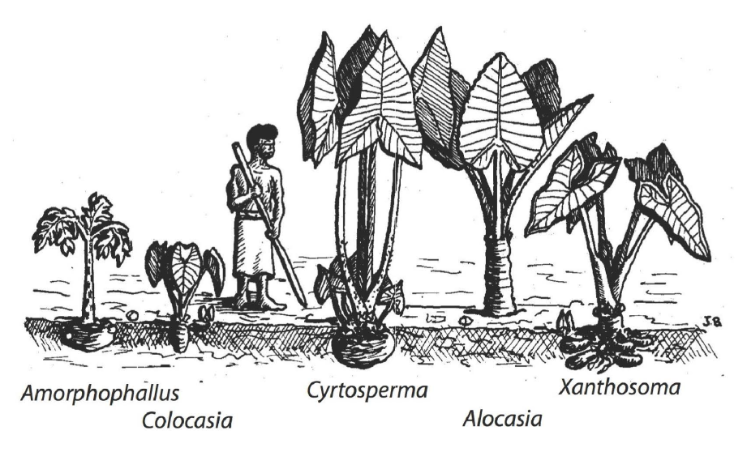

**Figure 9.3:** Taro (Araceae) genera and Amorphophallus: growth habit

| **PSOc** |  | *bʷeta | ‘taro, *Colocasia esculenta*’ (Lynch 2004a) |
| --- | --- | --- | --- |
| NCV | Mwotlap | *pʷet* | ‘taro, *Colocasia esculenta*’ |
| NCV | Ambae | *pʷeta* | ‘taro, *Colocasia esculenta*’ |
| NCV | Araki | *pera* | ‘taro, *Colocasia esculenta*’ |
| NCV | Raga | *bʷeta* | ‘taro, *Colocasia esculenta*’ |
| NCV | Nokuku | *pʷeta* | ‘taro, *Colocasia esculenta*’ |
| NCV | Kiai | *peta* | ‘taro, *Colocasia esculenta*’ |
| NCV | Tamambo | *bueta* | ‘taro, *Colocasia esculenta*’ |
| NCV | Sakao | *(oe)vad* | ‘taro, *Colocasia esculenta*’ |
| NCV | Uripiv | *na-bʷet* | ‘taro, *Colocasia esculenta*’ |
| NCV | Big Nambas | *na-pʷet* | ‘an edible root (not taro)’ |
| NCV | Lonwolwol | *(u)bʷer* | ‘taro, *Colocasia esculenta*’ |
| SV | Anejom̃ | *na-pʷat* | ‘k.o. taro’ |
| NCal | Nemi | *pʷeek* | ‘wild arrowroot, *Amorphophallus paeoniifolius* (?)’ |
| NCal | Jawe | *pʷeek* | ‘wild arrowroot, *Amorphophallus paeoniifolius* (?)’ |

The leaves of *Colocasia esculenta* are eaten as a green vegetable in many parts of Oceania, and many languages have a separate word for them (ch.4, §2.5). A possible POc term for taro leaves, POc *gal(a,o) is weakly supported, along with a possible PWOc candidate, *[qa]pʷasu - ‘possible’ because only its NNG and PT reflexes denote leaves; its MM reflexes denote *Colocasia esculenta* itself.

| **POc** |  | *gal(a,o) | ‘taro leaves’ (?) (Ross 1996d: 190) |
| --- | --- | --- | --- |
| Adm | Baluan | *gal* | ‘taro’ |
| NNG | Labu | *ka* | ‘taro’ |
| MM | Vitu | *galo* | ‘taro leaves’ |
| SES | Kwaio | *gala-* | ‘taro shoot’ |

| **PWOc** |  | *[qa]pʷasu | ‘taro leaves’ (?) |
| --- | --- | --- | --- |
| NNG | Kaulong | *pasu* | ‘(mature) taro leaf’ |
| NNG | Sengseng | *paso* | ‘taro leaf’ (A. Chowning, pers. comm.) |
| NNG | Manam | *(minam) ʔapʷas* | ‘k.o. yam’ |
| PT | Misima | *pʷasuwa* | ‘k.o. tree with edible leaves; *Gnetum gnemon*’ |
| MM | Kara (East) | *iavas* | ‘taro, *Colocasia esculenta*’ |
| MM | Madak | *pas* | ‘taro’ |
| MM | Patpatar | *pas* | ‘taro, *Colocasia esculenta*’ |
| MM | Tolai | *pa* | ‘taro, *Colocasia esculenta*’ |

Other terms for parts of the taro plant are reconstructed in chapter 4. They are

- POc *[s,j]uli(q) ‘banana or taro sucker, slip, cutting, shoot (i.e. propagation material)’ (ch.4, §2.6)[^12]
- POc *baRa-baRa ‘stem or stalk of non-woody plants, such as taro and banana, probably also the soft stems of leaves’ (ch.4, §2.2)
- POc *up(e,a) ‘taro seedling’ (ch.4, §2.6)

#### 2.2.2. *Cyrtosperma merkusii* (syn. *Cyrtosperma chamissonis*, *Cyrtosperma edule*), swamp taro, giant taro, P *kakake*, *kakama*, B *wota taro* (Araceae)

At 4 metres tall swamp taro, *Cyrtosperma merkusii*, is a giant among the Araceae. It grows wild or is cultivated in swampy areas on many of the islands of Melanesia, Polynesia and Micronesia. Cyrtosperma taro is commonly grown in the mud directly behind the mangrove swamp (Barrau 1955: 25-26). In pre-European times it was cultivated in the Bismarcks (on Manus and New Ireland), the Solomons, Vanuatu, Micronesia, western Polynesia and parts of Fiji but not on mainland New Guinea, in New Caledonia, or in eastern Polynesia (Barrau 1962: 103, Andrew Pawley, pers. comm.). It tolerates saline swamps and requires little labour to cultivate (Bourke 1982). Because of its suitability for marginal conditions, it is an important staple on atolls in Micronesia. Elsewhere it has only marginal importance as a food crop. It is propagated by planting cuttings in marshy ground, and the tuber, which may weigh up to 15 kg, is harvested only after three years or longer. It is usually cooked by baking (Barrau 1955: 53). Its huge waxy leaves are used in the Solomons for sealing stone ovens and for laying out food (Henderson & Hancock 1988: 29-30).

The reconstruction of a term for ‘swamp taro’ has a chequered history. In Ross (1996d) I proposed that the POc name for swamp taro was *bulaka, but indicated that there was a formal problem with this reconstruction. Its NCV reflexes lack a consonant corresponding to *-l-, and Clark (1996) accordingly reconstructed PNCV *buaga ‘taro’. Geraghty (1990: 57-58) observed that POc *R, but not *l, is often lost in NCV languages, and took this as evidence for PEOc *buRaka, rather than *bulaka, citing Nakanai *bureka* in support of this. This is just one of three Nakanai reflexes, however,[^13] and at least two out of the three must be borrowings.

Geraghty suggested that Polynesian reflexes were probably borrowings from Micronesian, and Barrau (1959) and Whistler (1991a: 47, 58-59) suggested that *Cyrtosperma merkusii* was indeed introduced into Polynesia from Micronesia. Kikusawa (2003) has expanded on this and argues that the Micronesian terms below, other than Marshallese, reflect Proto Chuukic-Ponapeic *pʷulaka ‘swamp taro, *Cyrtosperma merkusii*’ (Chuukic-Ponapeic is a subgroup of Micronesian), and that all the other terms listed below were borrowed directly or indirectly from a Chuukic-Ponapeic language.

Kikusawa may well be right,[^14] as Bourke (1990) suggests that Cyrtosperma taro was introduced into the Bismarcks by Polynesians living on the atolls to the east. Swamp taro is the dominant root crop only in Micronesia, and the irregularities of reflexes outside Micronesia and Polynesia cause difficulties both for my *bulaka and Geraghty’s *buRaka.[^15] In order to demonstrate this, I list against each reflex below the POc form that it **would** reflect if it were directly inherited. The Micronesian terms, other than Marshallese, reflect PChk-Ponapeic *pʷulaka, which reflects a hypothetical POc *bulaka. The Polynesian terms appear to reflect PPn *pulaka, also reflecting a hypothetical POc *bulaka. However, the claim in Ross (1996d) that they actually reflect POc *bulaka collapses as we move westward, as does Geraghty’s reconstruction of *buRaka. NCV terms consistently reflect PNCV *bu(R)aga, whilst MM and Adm reflexes are chaotic and typical of sets most or all of whose members are borrowed.

The items listed below denote ‘swamp taro, *Cyrtosperma merkusii*’ unless glossed otherwise.

| Adm | Mussau | *ulaa* | ‘swamp taro, *Cyrtosperma merkusii*’ (would reflect *pu(l,r,R)a(q,k)a) |
| --- | --- | --- | --- |
| Adm | Seimat | *hula* | ‘swamp taro, Alocasia sp., introduced from Aua’ (would reflect *pula(q,k)a)(Sorensen 1950) |
| Adm | Aua | *fuula* | ‘taro’ (would reflect *pula(q,k)a) |
| Adm | Lou | *pulak* | ‘swamp taro, *Cyrtosperma merkusii*’ (would reflect *(p,b)ulaka) |
| MM | Nakanai | *ula* | ‘an inedible wild taro, *Colocasia* sp.’ (would reflect *u(l,r,R)a(q,k)a) |
| MM | Nakanai | *buleha* | ‘an inedible wild taro, *Colocasia* sp.’ (would reflect *bu(l,r,R)eqa) |
| MM | Nakanai | *bureka* | ‘variety of elephant ear taro, *Alocasia macrorrhizos*’ (would reflect *buseqa) |
| MM | Kara (East) | *vuləi* | ‘k.o. taro’ (would reflect *hulaqa) |
| MM | Patpatar | *pulaka* | ‘Polynesian arrowroot, probably *Tacca leontopetaloides*’ (would reflect *pulaka)[^16] |
| MM | Tolai | *pulaka* | ‘Polynesian arrowroot, probably *Tacca leontopetaloides*’ (would reflect *pulaka) |
| NCV | Mota | *puaka* | ‘boggy ground, mud’ (would reflect *hu(R)aga) |
| NCV | Uripiv | *ʙuak* | ‘(rare) taro’ (would reflect *hu(R)aga) |
| NCV | Big Nambas | *bōak* | ‘taro, *Colocasia* sp.’ (would reflect *hu(R)aga) |
| NCV | Port Sandwich | *ᵐbuaᵑg* | ‘hill taro’ (would reflect *hu(R)aga) |
| NCV | Naman | *buag* | ‘swamp taro, *Cyrtosperma merkusii*’ (would reflect *hu(R)aga) |
| NCV | Neve’ei | *ni-biaŋ* | ‘swamp taro, *Cyrtosperma merkusii*’ (would reflect *hu(R)aga) |
| NCV | Avava | *ʙuaŋ* | ‘swamp taro, *Cyrtosperma merkusii*’ (would reflect *hu(R)aga) |
| NCV | Nese | *boak* | ‘swamp taro, *Cyrtosperma merkusii*’ (would reflect *hu(R)aga) |
| NCV | Namakir | *buag* | ‘swamp taro, *Cyrtosperma merkusii*’ (would reflect *hu(R)aga) |
| NCal | Xârâcùù | *buraa* | ‘variety of taro’ (would reflect ?) |
| Mic | Marshallese | *pɯəl* | ‘swamp taro patch’ (would reflect *hulaqa) |
| Mic | Mortlockese | *pʷulᴂ* | ‘swamp taro, *Cyrtosperma merkusii*’ (would reflect *hula(q,k)a) |
| Mic | Trukese | *pʷuɾa* | ‘swamp taro, *Cyrtosperma merkusii*’ (would reflect *hula(q,k)a) |
| Mic | Puluwatese | *pʷula* | ‘swamp taro, *Cyrtosperma merkusii*’ (would reflect *hula(q,k)a) |
| Mic | Satawalese | *pʷula* | ‘swamp taro, *Cyrtosperma merkusii*’ (would reflect *hula(q,k)a) |
| Mic | Carolinian | *bʷula* | ‘swamp taro, *Cyrtosperma merkusii*’ (would reflect *hula(q,k)a) |
| Mic | Woleaian | *fʷuraxe* | ‘swamp taro, *Cyrtosperma merkusii*’ (would reflect *hulaka) |
| Mic | Pulo-Annan | *vʷuraxa* | ‘swamp taro, *Cyrtosperma merkusii*’ (would reflect *hulaka) |
| Pn | Anutan | *pulaka* | ‘swamp taro, *Cyrtosperma merkusii*’ (would reflect *hulaka) |
| Pn | Pukapukan | *pulaka* | ‘swamp taro, *Cyrtosperma merkusii*’ (would reflect *hulaka) |
| Pn | East Futunan | *pulaka* | ‘swamp taro, *Cyrtosperma merkusii*’ (would reflect *hulaka) |
| Pn | East Uvean | *pulaka* | ‘swamp taro, *Cyrtosperma merkusii*’ (would reflect *hulaka) |
| Pn | Samoan | *pulaʔa* | ‘swamp taro, *Cyrtosperma merkusii*’ (would reflect *hulaka) |
| Pn | Tuvalu | *pulaka* | ‘swamp taro, *Cyrtosperma merkusii*’ (would reflect *hulaka) |
| Pn | Tokelauan | *pulaka* | ‘swamp taro, *Cyrtosperma merkusii*’ (would reflect *hulaka) |
| Pn | Rarotongan | *puraka* | ‘coarse kind of taro’ (would reflect *hulaka) |

#### 2.2.3. *Alocasia macrorrhizos* (syn._Alocasia macrorrhiza_, *Alocasia indica*), giant taro, elephant ear taro, P *waeltaro* (Araceae)

The giant taro, *Alocasia macrorrhizos*, growing to 3-4 m, is not strictly a root crop; it is the corm (i.e. the thick lower stem) that is eaten. It is present as a minor staple in much of New Guinea and the Bismarcks, but appears to have been grown as much for ceremonial significance as for eating (Bourke 1982). Ann Chowning (pers. comm.) reports that among the Nakanai and the Sengseng of New Britain, giant taro is often eaten by people who are abstaining from *Colocasia* taro as an act of mourning for a dead relative. *Alocasia macrorrhizos* is not mentioned at all in Henderson and Hancock’s (1988) Solomons survey. Barrau (1955: 54) says that it is found throughout Melanesia but only sometimes cultivated in gardens, Hay (1990: 41-42) that it is uncommon in rural Papua New Guinea. Its calcium oxalate content is such that it requires lengthy baking or scalding with water several times.

The POc name for giant taro was *piRaq, continuing a PMP etymon. The final *-q is attested in Gumawana, Bwaidoga, Big Nambas and Tape and indirectly in the retention of the final vowel in SV languages (Lynch 2001c: 121).

| **PMP** |  | *biRaq | ‘taro sp.’ (Blust 1972b) |
| --- | --- | --- | --- |
| **POc** |  | *piRaq | ‘giant taro, elephant ear taro, *Alocasia macrorrhizos*’ (Blust 1972b) |
| Adm | Mussau | *ia* | ‘*Alocasia macrorrhizos*’ |
| PT | Gumawana | *vilava* | ‘taro’ |
| PT | Bwaidoga | *vilaɣa* | ‘edible root resembling taro’ |
| PT | Motu | *hira* | ‘large sp. of edible arum’ |
| MM | Kara (East) | *fia* | ‘*Alocasia macrorrhizos*’ |
| SES | Gela | *vita* | ‘*Alocasia macrorrhizos*’ |
| SES | Arosi | *hira* | ‘*Alocasia macrorrhizos*’ |
| NCV | Mwotlap | *vı* | ‘*Alocasia macrorrhizos*’ |
| NCV | Mota | *via* | ‘the giant caladium’ |
| NCV | Ambae | *via* | ‘*Alocasia macrorrhizos*’ |
| NCV | Kiai | *via* | ‘*Alocasia macrorrhizos*’ |
| NCV | Araki | *via* | ‘*Alocasia macrorrhizos*’ |
| NCV | Raga | *via* | ‘*Alocasia macrorrhizos*’ |
| NCV | Big Nambas | *ðᫀix* | ‘*Alocasia macrorrhizos*’ (J. Lynch, pers. comm.) |
| NCV | Uripiv | *na-vi* | ‘wild arrowroot, *Amorphophallus paeoniifolius*’ |
| NCV | Tape | *viaɣ* | ‘*Cyrtosperma merkusii*’ |
| NCV | Nese | *na-dᫀi* | ‘k.o. taro’ |
| NCV | Big Nambas | *viah* | ‘*Alocasia macrorrhizos*’ |
| NCV | Southeast Ambrym | *o-hia* | ‘unidentified edible tuber’ |
| NCV | Paamese | *u-hiaa* | ‘wild yam’ |
| NCV | Lewo | *ko-yuia* | ‘(wild) yam’ |
| NCV | Namakir | *vi* | ‘Cyrtosperma?’ |
| NCV | Nguna | *na-via* | ‘taro sp., inedible; very bitter or acidic; said to burn the mouth if eaten’ |
| NCV | South Efate | *na-fi* | ‘taro sp.’ |
| SV | Sye | *ne-vye* | ‘water taro’ |
| SV | Lenakel | *nu-via* | ‘k.o. taro’ |
| SV | Kwamera | *nu-via* | ‘Crytosperma (wild taro)’ |
| SV | Anejom̃ | *nehei* | ‘*Alocasia macrorrhizos*’ |
| NCal | Pije | *pia* | ‘*Alocasia macrorrhizos*’ |
| NCal | Fwai | *pia* | ‘*Alocasia macrorrhizos*’ |
| NCal | Nemi | *pia* | ‘*Alocasia macrorrhizos*’ |
| NCal | Jawe | *pia* | ‘*Alocasia macrorrhizos*’ |
| NCal | Nêlêmwâ | *pia* | ‘*Alocasia macrorrhizos*’ |
| Fij | Wayan | *via* | ‘giant taro, Alocasia and Cyrtosperma spp.; cultivated but eaten only in time of famine’ |

#### 2.2.4. Another term for taro?

The glosses suggest that the denotatum of POc *(p,b)oso below belonged to the Araceae family, but it is impossible to infer its identity from the available data.

| **POc** |  | *(p,b)oso | ‘k.o. taro’ |
| --- | --- | --- | --- |
| NNG | Barim | *bus* | ‘taro’ |
| NNG | Lukep (Pono) | *bus* | ‘taro’ |
| MM | Madak | *pos* | ‘grealter yam’ |
| Mic | Kosraean | *ɔt* | ‘taro sp.’ |
| Mic | Marshallese | *wetɯ* | ‘elephant ear taro, *Alocasia macrorrhizos*’ |
| Mic | Trukese | *wōt* | ‘taro, *Colocasia esculenta*’ |

### 2.3. Other tubers

Three other tubers are quite widely distributed in the Pacific. Two are the wild arrowroot, *Amorphophallus paeoniifolius* (syn. *Amorphophallus campanulatus*), and the Polynesian arrowroot, *Tacca leontopetaloides*, but I am unable to reconstruct a POc term for either. This suggests either that they, too, are more recent introductions or, more probably, that they are rarely eaten and have undergone frequent renaming. The third tuber is *Pueraria lobata*, apparently more widely cultivated in earlier times than it is today.

#### 2.3.2. *Tacca leontopetaloides*, Polynesian arrowroot (Taccaceae)

The tuber of *Tacca leontopetaloides* is bitter and requires considerable processing to produce a starch pudding somewhat like sago pudding. It was used in this way on the small islands of the SE Solomons and the Temotu Province, and in much of Polynesia (Henderson & Hancock 1988: 34) but apparently had only limited use in the Bismarcks.

Interestingly, almost all the names I have collected for it reflect a reassignment of the name of some other starchy food:

| MM: | Patpatar | *pulaka* | < *bulaka ‘*Cyrtosperma merkusii*’ (§2.2.2) |
| --- | --- | --- | --- |
| MM: | Tolai | *pulaka* | < *bulaka ‘*Cyrtosperma merkusii*’ (§2.2.2) |
| TM: | Aiwoo | *(to)piya* | < POc *piRaq ‘*Alocasia macrorrhizos*’ (§2.2.3) |
| Fij: | Bauan | *yabia* | < POc *Rabia ‘*Metroxylon sagu*’ (§5.1) |
| Pn: | Pileni | *pia* | < POc *Rabia ‘*Metroxylon sagu*’ (§5.1) |
| Pn: | Rarotongan | *pia* | < POc *Rabia ‘*Metroxylon sagu*’ (§5.1) |

The elements in the PPn binomial below are PPn *ma ‘fermented breadfruit’ (POLLEX) and *soaʔa ‘banana’ (§3).

| **PPn** |  | *mā-soaʔa | ‘Polynesian arrowroot, *Tacca* sp.’ (POLLEX) |
| --- | --- | --- | --- |
| Pn | Tongan | *māhoaʔa* | ‘arrowroot, *Tacca* sp.’ |
| Pn | Tokelauan | *mahoā* | ‘*Tacca leontopetaloides*’ |
| Pn | Anutan | *maoa* | ‘arrowroot, *Tacca* sp.’ |
| Pn | East Futunan | *māsoʔā* | ‘arrowroot, *Tacca* sp.’ |
| Pn | Samoan | *māsoā* | ‘*Tacca leontopetaloides*’ |
| Pn | Tuvalu | *māsoa* | ‘arrowroot, *Tacca* sp.’ |

For the Micronesian names of *Tacca leontopetaloides*, however, no origin has been found: Nauru *(da)mag-mag*, Proto Western Micronesian *mʷaku-mʷaku ’arrowroot, *Tacca leontopetaloides* (Bender et al. 2003).

#### 2.3.3. *Pueraria lobata* (syn. *P. novo-guineensis*, *Pueraria thunbergiana*, *Pueraria triloba*, *Pueraria hirsuta*, *P. neo-caledonica*, *Pachyrrhizus trilobus*, *Pueraria montanus*, P. *Dolichos hirsutus*, *Dolichos tuberosus*, *Dolichos lobatus*) (Fabaceae)

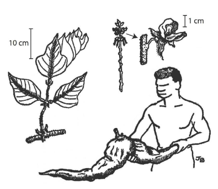

**Figure 9.4:** Tuber and plant parts of *Pueraria lobata*

Pueraria species are half-woody lianas, 3-5m high, with stems covered in hairs, brown on older parts, rust-yellow to white on younger. The bast is used to make yam for rope, fishing lines and fish nets. One species, *Pueraria lobata* (with an enormous number of synonyms), is found as far east as Samoa.

*Pueraria lobata* has a fleshy, tapioca-like tuber that is widely eaten in times of famine (Barrau 1965; Peekel 1984: 253-255). Barrau (1965) supports Guppy’s (1906: 412) suggestion that *Pueraria lobata* may also have been more widely cultivated by Oceanic speakers before the arrival of the sweet potato. It is still cultivated in the Kangean Islands (120 km east of Madura, Indonesia) and in New Caledonia, where Haudricourt (1964: 97), cited by Barrau, labels it ‘a food for chiefs’ rather than a famine food. One of Guppy’s mid-nineteenth-century sources noted that it also had ceremonial significance in Fiji.

No POc term for *Pueraria lobata* is reconstructable, and the cognate set below is restricted to North-Central Vanuatu and Central Pacific, and thus allow only a PROc reconstruction. None of Barrau’s sources make specific mention of the Bismarcks or the Solomons, and it may be that its significance has faded more definitely from folk memory there than on smaller islands where it still serves as a famine food.

The gloss of the Raga reflex refers to famine food, and probably denotes *Pueraria lobata*.

| **PROc** |  | *Raka | ‘k.vine, *Pueraria lobata*’ (Geraghty 1990) |
| --- | --- | --- | --- |
| NCV | Raga | *aga* | ‘yam with blue flowers, eaten in time of famine’ |
| NCV | Port Sandwich | *ni-ax* | ‘vine sp.’ |
| NCV | Paamese | *e-ā* | ‘kind of tree with very tough roots that are very tough to dig out while hoeing in garden’ |
| NCV | Namakir | *ni-ak* | ‘vine sp. with blue flowers like a yam; Pueraria (?)’ |
| Fij | Wayan | *aka* | ‘creeper, *Pueraria lobata*’ |
| Fij | Bauan | *yaka* | ‘creeper, *Pueraria lobata*’ (Geraghty 2004: 79) |
| Pn | Tongan | *aka* | ‘creeper, *Pueraria lobata*, whose root is eaten when better food is scarce’ |
| Pn | Niuean | *aka* | ‘*Pueraria lobata*’ |
| Pn | Ifira-Mele | *aka* | ‘creeper sp., probably *Pueraria lobata*’ |
| Pn | Pukapukan | *aka* | ‘a root’ |
| Pn | Rennellese | *aka* | ‘bush vine, *Pueraria lobata* with long roots, eaten in times of shortage’ |
| Pn | Tikopia | *aka* | ‘root of *Pueraria lobata*’ |
| Pn | Samoan | *aʔa* | ‘creeper, *Pueraria lobata*’ |
| Pn | Tokelauan | *aka* | ‘root’ |
| Pn | Māori | *aka* | ‘Metrosideros spp. that begin life as climbing vines.’ |

## 3. Bananas, cultivars of the genus *Musa*

Banana plants have a non-woody stem and huge leaves which, along with the stem holding the bunches of bananas, grow directly out of the top of the main stem. The plant as a whole is usually around 3 m in height.

In Papua New Guinea today bananas are the second most widely consumed food crop after the sweet potato. For some PNG communities starchy varieties of bananas are the sole staple, picked and cooked before they are fully ripe. Some varieties lend themselves better to boiling, others to baking. Traditional banana varieties are relatively hard to grow; each year they must be moved to new garden sites with fertile soil. Many of these varieties produce fruit within six months of planting (French & Bridle 1978: 12). Figure 9.5 shows a traditional banana plant.

Banana leaves have a variety of uses. The most common are wrapping food for baking in a stone oven (vol.1, ch.6, §3.1) and laying out food on them at feasts.

Edible bananas are all sterile hybrids with complex genetic histories, cultivars of the genus *Musa*.[^17] In my 1996 attempt to gloss the various reconstructed terms for bananas, I employed the old division, based on morphological characteristics, of the genus *Musa* into five sections, varieties of which found in NW Melanesia belong to the sections Eumusa and Australimusa. In the past fifty years a new understanding of *Musa* sections has emerged, resulting in a reduction in their number from five to three, but two are still relevant to NW Melanesia, namely *Musa* [^18] (including the former Eumusa) and Callimusa (including the former Australimusa) (Simmonds & Shepherd 1955, Wong et al. 2002). In Simmonds and Shepherd’s cultivated banana nomenclature, each section contains species (plus subspecies) and hybrids, the latter labelled with letters denoting the subspecies from which they are derived:

A for the various subspecies of *Musa* acuminata, B for those of *Musa balbisiana*, S for the minor New Guinea species *Musa schizocarpa* (all three in the section *Musa*) and T for Callimusa-derived genomes. Thus ‘*Musa sapientum*’ and ‘*Musa paradisiaca*’, the two alleged species recognised by Linnaeus, are both AAB triploid hybrids. Arnaud and Horry’s (1997) survey of 108 banana varieties in Papua New Guinea includes AA and AB diploid and AAA, AAB and ABB triploid hybrids, as well as hybrids of *Musa* and Callimusa species.[^19]

Biomolecular study confirms these sections and is currently bringing about a revision of ideas about the archaeobotany of bananas, which is considerably more complicated than previously thought (J. Kennedy forthcoming). The transformation from wild to cultivated edible bananas occurred independently in the two sections. The wild species of the section *Musa* that have contributed to edible bananas are found over a region stretching from eastern India and Sri Lanka through island SE Asia into the NW Melanesia as far as the Solomons, but the fact that New Guinea is home to many highly diverse diploid AA cultivars makes it the probable area of their domestication. Wild Callimusa species are confined to a region stretching from Halmahera to the Solomons, indicating that NW Melanesia was the region where Callimusa bananas were also first domesticated.

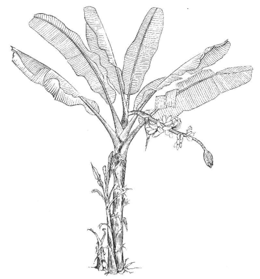

**Figure 9.5:** Traditional (diploid) banana plant

J. Kennedy (2008) points out that all bananas east of the Solomons were carried there by settlers. These belong to three distinct lineages. The first consists of so-called *Fe’i* bananas, hybrids among several Callimusa species (and the world’s only edible Callimusa bananas). The other two, both known as ‘Pacific plantains’, are derived from *Musa* species. One involves *Musa acuminata*, subspecies banksii, endemic to New Guinea, and the other is a cross between the *Musa acuminata* subspecies banksii and errans, the latter endemic to the Philippines. *Fe’i* bananas and banksii derivatives both originated in New Guinea, but the site of banksii/errans hybridisation is unknown. Archaeological evidence from Kuk in the New Guinea Highlands indicates that edible diploids derived from *Musa acuminata* banksii were under cultivation by 7000 years ago, but the origins of *Fe’i* bananas and banksii/errans hybrids cannot be dated. The geographic and chronological unknowns do not exclude the possibility that all three lineages were carried into the Pacific by early Oceanic speakers, but they do not confirm it either.

The likelihood that banana domestication first occurred in New Guinea, and that edible bananas spread from there into Asia and Africa, means that any bananas brought to New Guinea and the Bismarcks by Austronesian speakers probably came from this region in the first place. That bananas have long been a part of their diet is confirmed by the very well attested PMP term *punti and its POc continuation *pudi. The fact that its reflexes are so widespread makes it certain that this was the generic term for bananas. Today’s Oceanic speakers usually have numerous terms for the different banana cultivars in their gardens, but the fact that few people use Simmonds and Shepherd’s nomenclature in glosses (and that old terms persist) makes it difficult or impossible to provide scientific names for these. Because of this difficulty, old species terms are retained in glosses.

| **PMP** |  | *punti | ‘banana’ (Dempwolff 1938) |
| --- | --- | --- | --- |
| **POc** |  | *pudi | ‘banana, *Musa* cultivars’ (Capell 1943: *puti) |
| Adm | Mussau | *uri* | ‘banana’ |
| Adm | Seimat | *pudi* | ‘*Musa* sp.’ (Sorensen 1950) |
| Adm | Drehet | *puŋ* | ‘banana’ |
| NNG | Poeng | *puri* | ‘banana’ |
| NNG | Kove | *puri* | ‘banana’ |
| NNG | Lukep (Pono) | *pur* | ‘banana’ |
| NNG | Gitua | *pudi* | ‘banana’ |
| NNG | Mapos Buang | *vud* | ‘banana’ |
| PT | Tubetube | *udi* | ‘banana’ |
| MM | Nakanai | *vugi* | ‘banana’ |
| MM | Bulu | *vudi* | ‘banana’ |
| MM | Tigak | *ur* | ‘banana’ (Beney 1980) |
| MM | Tolai | *vudu* | ‘banana’ |
| TM | Äiwoo | *no-u* | ‘banana’ |
| SES | Gela | *vudi* | ‘banana’ |
| SES | To’aba’ita | *fudi* | ‘banana’ (archaic) |
| SES | Lau | *fudi* | ‘banana’ |
| SES | Sa’a | *huti* | ‘banana’ |
| NCV | Naman | *nə-vəj* | ‘banana’ |
| NCV | Nese | *no-ðᫀic* | ‘banana’ |
| NCV | Uripiv | *na-vij* | ‘banana’ |
| NCV | Lonwolwol | *vih* | ‘banana’ |
| NCV | Port Sandwich | *na-vüc* | ‘banana’ |
| NCV | Nguna | *na-adi* | ‘banana’ |
| SV | Sye | *no-voh* | ‘banana’ |
| SV | Anejom̃ | *no-hos* | ‘banana’ |
| NCal | Pije | *piji(ŋ)* | ‘*Musa paradisiaca*’ |
| NCal | Xârâcùù | *pwî* | ‘banana’ |
| NCal | Iaai | *o-vic* | ‘banana’ |
| Mic | Kosraean | *uṣ* | ‘banana’ |
| Mic | Mokilese | *wus* | ‘banana’ |
| Mic | Ponapean | *ūt* | ‘banana’ |
| Mic | Trukese | *wūc̣* | ‘banana’ |
| Mic | Puluwatese | *wūṛ* | ‘banana’ |
| Mic | Satawalese | *wūṛ* | ‘banana’ |
| Mic | Woleaian | *wīṣi* | ‘banana’ |
| Fij | Wayan | *vudi* | ‘cooking banana; sometimes used as generic term for banana’ |
| Pn | Tongan | *fusi* | ‘cooking banana or banana of any kind’ |

The term *Musa troglodytarum* is used (inaccurately) both of wild varieties of *Musa balbisiana* and of *Fe’i* bananas. In the Uripiv and Samoan glosses below it is likely that it denotes the latter, in agreement with the Bauan gloss. POc *joRaga is glossed accordingly, but with a question mark, because this was the meaning of the PROc reflex but not necessarily of the POc term. *Fe’i* bananas are uncommon in New Guinea today, and it is not clear whether they were present in the Bismarcks in Proto Oceanic times.

| **POc** |  | *joRaga | ‘banana, Fe”i (?) cultivars’ |
| --- | --- | --- | --- |
| NNG | Silisili | *cok* | ‘banana’ |
| NNG | Patep | *joŋ* | ‘banana (generic); banana, *Musa sapientum*’ |
| MM | Vaghua | *soga* | ‘banana’ |
| SES | Arosi | *toraga* | ‘banana sp.’ |
| NCV | Raga | *hoaga* | ‘k.o. banana’ |
| NCV | Uripiv | *jok* | ‘*Musa troglodytarum*, a kind of banana’ |
| NCV | Paamese | *sōko* | ‘kind of banana with large orange coloured fruit’ |
| NCV | Nguna | *soaga* | ‘cooking banana’ |
| Fij | Bauan | *soaga* | ‘banana sp., *Musa fehi*’ |
| Pn | Samoan | *soaʔa* | ‘mountain plantain, *Musa troglodytarum*’ (Whistler 2000: 7) |

The glosses of the four terms below are vague, both because the glosses of present-day forms are often vague and for the reasons given above, but they appear to have denoted banana cultivars. POc *sakup perhaps denoted a cultivar with long fruit, as the glosses of its Gumawana, Motu and Kwara’ae reflexes suggest. In view of its upright bunches Kwara’ae *sa-sao* appears to denote a *Fe’i* cultivar (J. Kennedy, pers. comm.), but this is neither confirmed nor disconfirmed by the glosses of its cognates. It is probable that POc *bʷera was a descriptive term meaning ‘white’, since Puluwat *pʷer* retains this meaning. The POc form is probably a reflex of PMP *burak ‘white’. If so, one may infer that it referred to bananas of the *Musa* group, since *Fe’i* bananas are typically copper-coloured.

| **POc** |  | *sakup | ‘banana cultivar with long fruit’ (?) |
| --- | --- | --- | --- |
| PT | Gumawana | *yagowa* | ‘a long non-sweet banana’ |
| PT | Taupota | *hakova* | ‘banana’ |
| PT | Taboro | *daua* | ‘k.o. banana: white flesh’ |
| PT | Motu | *dau* | ‘k.o. banana: very long’ |
| MM | Roviana | *hakua* | ‘banana’ |
| MM | Maringe | *cau* | ‘banana’ |
| SES | Kwara’ae | *sa-sao* | ‘k.o. banana with upright bunches and large fruit’ |
| SES | ’Are’are | *sao-sao* | ‘k.o. wild banana’ |
| NCV | Ambae | *haka* | ‘banana’ |
| NCV | Larëvat | *(nəv)saɣ* | ‘banana’ |
| NCV | Tape | *(ni)saɣ* | ‘banana’ |
| NCV | Paamese | *sou-sou* | ‘k.o. banana’ |

| **POc** |  | *bʷera | ‘*Musa* cultivar’ |
| --- | --- | --- | --- |
| PT | Gapapaiwa | *bora-bora* | ‘k.o. banana’ |
| PT | Budibud | *bʷela-mʷela* | ‘banana’ |
| NCV | Paamese | *a-voi* | ‘k.o. banana’ |
| Mic | Puluwatese | *(wuṛu)pʷeṛ* | ‘k.o. banana enjoyed cooked’ |

| **POc** |  | *baqun | ‘banana cultivar’ |
| --- | --- | --- | --- |
| Adm | Loniu | *pakɔw* | ‘k.o. wild banana’ |
| MM | Teop | *pauna* | ‘banana; kidney’ |
| SES | To’aba’ita | *baʔu* | ‘banana plant and fruit’ (syn. *fudi*, now archaic) |
| SES | Dori’o | *baʔu* | ‘banana’ |
| **PSV** |  | *n-ban | ‘banana (generic)’ (Lynch 2004a) |
| SV | Sye | *ni-mpa* | ‘k.o. banana with long fruit’ |
| SV | Lenakel | *nə-pən* | ‘banana’ |
| SV | Southwest Tanna | *nə-pʷan* | ‘banana’ |
| Mic | Puluwatese | *(wuṛu)pāwo* | ‘k.o. cooking banana’ |

cf. also:

| NNG | Mato | *baɣup* | ‘banana’(Stober 2005) |
| --- | --- | --- | --- |

| **PWOc** |  | *bʷatiq | ‘banana cultivar’ |
| --- | --- | --- | --- |
| PT | Tawala | *bihiya* | ‘banana plant’ |
| PT | Misima | *bʷahiki* | ‘banana’ |
| PT | Nimoa | *bʷasihe* | ‘banana’ |
| MM | Vitu | *beti* | ‘banana’ |
| MM | Vangunu | *batia* | ‘banana’ |

There is evidence for PWOc *pudi-pudi ‘wild banana’, a transparent reduplication of the generic POc term for banana (see ch. 2, §7.2).

| NNG | Mangap | *pin-pin* | ‘wild banana’ |
| --- | --- | --- | --- |
| PT | Sudest | *ɣudu-ɣudu* | ‘wild banana seeds’ |
| MM | Ramoaaina | *udu-udu* | ‘wild banana’ |
| MM | Tolai | *vudu-vudu* | ‘wild banana, *Ensete glaucum*’(Arnaud and Horry 1997: 19) [^20] |

Names for the various parts of the banana plant are discussed in chapter 4. Some are also mentioned in §2.2.1, as they are also used for the taro (and probably for other plants, too). Sorting out glosses is sometimes difficult, but the following inferences appear to be well founded (section numbers refer to ch. 4): the banana plant has a main stem, *baRa-baRa (§2.2) of its own, from which protrudes a stem holding a bunch, *puŋu (§2.8) of bananas, from which in turn grow small stems, *kulo (§2.8) each holding a hand, *qitiŋ (§2.8) of bananas.[^21] A new banana plant is planted with a slip or cutting, *[s,j]uli(q) (§2.6), and the new growth first appears as a shoot, *qili (§2.6).

## 4. *Artocarpus altilis* (syn. *Artocarpus communis*, *Artocarpus incisus*), breadfruit, TP *kapiak*, P *beletiutu* (Moraceae)

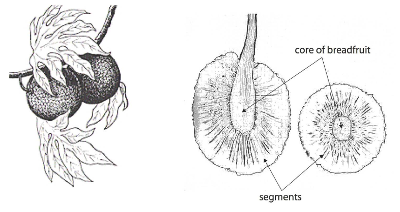

**Figure 9.6:** Fruit, leaves and sections of breadfruit, *Artocarpus altilis*

Breadfruit trees grow throughout the Oceanic-speaking region, except for New Zealand and the Chatham Islands. Breadfruit tend to be co-staples with other starchy foods, providing starch when the other staples are out of season and vice versa. In Melanesia it is most significant as a staple in the Temotu Province of the Solomons, but is also important in SE Papua, the Bismarcks and Bougainville,[^22] on the coasts of the islands of Vanuatu, in Micronesia, in Fiji and in parts of Polynesia (Henderson & Hancock 1988:36, Walter & Sam 2002: 107-108).

Breadfruit trees grow to a height of 20 m and usually at altitudes below 1200 m. They are fairly tolerant with regard to soil, and grow in the coral soils of atolls. In the South Pacific, a tree yields 50 to 150 ovoid grapefruit-sized pale yellow to yellow-orange fruit per (annual) season. In some areas there is a second smaller fruiting halfway between main annual fruitings. The breadfruit is a syncarp, a compound fruit with many segments arranged around the core, which itself is the spike of the original flower. Each segment contains a seed surrounded by flesh and growing from the core on a fleshy receptacle. The segments are visible on the skin of the fruit as hexagon-like shapes, as shown in Figure 9.6. A breadfruit may weigh as much as 5 kg.

Breadfruit seeds have a high protein content and are nutritionally the most valuable part of the fruit (Paijmans 1976: 123). Breadfruit are very rich in starch and contain about 25% carbohydrates. They are usually roasted, baked, fried, or boiled before being eaten. The cooking method depends on the cultivar. They can be eaten raw, but in Papua New Guinea and the Solomons they are commonly baked whole in a fire or an oven, and then the skin and seeds are removed. Some fruit have seeds about the size and texture of chestnuts and taste rather like very dense young potatoes. They are removed from the baked fruit and sometimes roasted over the fire before eating. In New Guinea this is usually the only part that is eaten (Walter & Sam 2002: 107-110, Bourke & Allen forthcoming).

The description above applies to breadfruit varieties in New Guinea and the Bismarck Archipelago. As one moves eastward across the Pacific, one finds breadfruit varieties that have been increasingly selected for flesh rather than seeds, so that most cultivars in Polynesia are seedless and are propagated by root cuttings. The genetic history is more complex than this implies, however, as two other species have contributed to the varieties subsumed under *Artocarpus altilis*. One is *Artocarpus camansi*, sometimes called ‘breadnut’, which occurred both wild and cultivated in New Guinea, the other *Artocarpus mariannensis*, endemic to the high islands of western Micronesia (Yen 1991, Zerega 2003, cited by Kennedy & Clarke 2004).

Because breadfruit trees usually produce large crops at certain times of the year, preservation is an issue. In parts of Papua New Guinea and in the Temotu archipelago, breadfruit are dried into a sort of biscuit (French & Bridle 1978:40, Henderson & Hancock 1988: 37). A traditional preservation technique in Vanuatu, Micronesia and Polynesia is to bury peeled and washed fruits in a leaf-lined pit where they ferment over several weeks and produce a sour, sticky paste. So stored, the product may last a year or more, and some pits are reported to have produced edible contents more than 30 years later (for terms associated with fermentation, see vol.1, ch.6, §4.2).

A common breadfruit product is a mixture of cooked or fermented breadfruit mash mixed with coconut milk and baked in banana leaves. In Vanuatu breadfruit are sometimes grated before cooking, or made into small balls and cooked in coconut milk.

All parts of the tree yield latex, a milky juice, which is used in some locations for boat caulking. At least in parts of New Britain and Vanuatu it is used to catch birds (Powell 1976, Walter & Sam 2002: 109). It also has medicinal uses. On Manus (Admiralties) the latex is diluted and drunk as treatment for dysentry, diarrhoea and stomach ache (O’Collins & Lamothe 1989). On Vanua Lava (Banks Islands, Vanuatu) latex from the breadfruit is mixed with latex from *Ficus adenosperma* as a potion against excessive menstrual discharge (Bourdy & Walter 1994). It is also used in Vanuatu to ‘patch’ damaged yams for storage (Walter & Sam 2002: 109).

The Bola and the Nakanai of New Britain beat the inner bark into cloth and use it for articles of clothing, including rain capes and it was formerly also used in this way in Tonga (Floyd 1954, Powell 1976, Walter & Sam 2002: 109). Infusions of the bark and leaves are used to treat disorders of the digestive tract in parts of Vanuatu. The wood sometimes serves for making outriggers and paddles and for firewood.

Two POc terms for ‘breadfruit’ are reconstructed with reasonable certainty, *kuluR and *baReko, whilst a third, *beta, is less well supported.

Reflexes of POc *baReko are found in New Ireland (MM), NW Solomonic (MM), SE Solomonic, Temotu, North-Central and Southern Vanuatu. In three Central Papuan languages, Lala, Roro and Kuni, the reflex of *baReko denotes ‘sago palm’, a shift from one starch source to another. In the sense ‘breadfruit’, reflexes of *kuluR~*kunuR and *baReko are geographically in complementary distribution. The distribution of *baReko forms an uninterrupted block across much of Island Melanesia excluding New Caledonia, with reflexes of *kuluR~*kunuR across most of the remaining Oceanic-speaking region. Just two reflexes of *baReko in the sense ‘breadfruit’ occur outside the block. One is Tawala *beleha*, which displays the wrong vowels and may be a chance resemblance. The other is Tomoip *buŋ-biria*.[^24] Tomoip is situated near the languages of the Mengen family (NNG), but it is a New Ireland outlier (Ross 1988: 292-293) and as such is an extension from the block.

How are we to explain the complementary distribution? It is clear from non-Oceanic cognates and from its Oceanic distribution that the usual POc term for breadfruit was *kuluR. But on our criteria for POc reconstruction (ch. 1, §3.2.3) *baReko must also be reconstructed to POc, as it is reflected in Westem Oceanic (MM), SE Solomonic, Temotu, and North and South Vanuatu. The distributions suggest that POc *kuluR was the default term for *Artocarpus altilis* and that it was then replaced by *baReko in a block from New Ireland to South Vanuatu. However, the reflexes of *baReko are generally regular, suggesting that replacement took place very early in the history of Oceanic.[^25]

POc *baReko or perhaps *beta may have denoted *Artocarpus camansi* or a particular breadfruit cultivar or, for example, the cooked breadfruit, but these possibilities remain speculations.

Scattered areas - many North New Guinea languages on New Britain, scattered languages in the islands of the Papuan Tip area, much of Central and South Vanuatu, and Micronesia - have a breadfruit term other than *kuluR~*kunuR and *baReko. Two of these, POc(?) *beta and PROc *maRi, are sufficiently widespread to warrant mention.

POc (?) *beta has a more restricted distribution: its reflexes occur in the New Georgia group, within SE Solomonic only in Gela, and in North-Central Vanuatu. This distribution requires that it be reconstructed for POc. The fact that its only non-Eastern Oceanic reflexes are in Nduke and Roviana in New Georgia in the northwest Solomons raises the possibility that *beta is a PEOc term that has been borrowed westward, but there is no other evidence I know of for Eastern Oceanic loans in New Georgia.

A fourth term, PROc *maRi ‘breadfruit’, is limited to South Vanuatu, Micronesian and Polynesian, but Geraghty (2004: 88) attributes Polynesian reflexes of the form *mei* (presumably for †*mai* or †*mal*) to borrowing, presumably from a Micronesian source. Again the distribution requires an explanation, this time because it is bipartite, but I can provide none.

| **PMP** |  | *kuluR | ‘breadfruit, *Artocarpus altilis*’ (Dempwolff 1938) |
| --- | --- | --- | --- |
| **POc** |  | *kuluR | ‘breadfruit, *Artocarpus altilis*’ |
| Adm | Mussau | *ulu* | ‘breadfruit’ |
| Adm | Loniu | *kun* | ‘breadfruit’ |
| Adm | Titan | *kul* | ‘breadfruit’ |
| Adm | Ponam | *gul* | ‘breadfruit’ |
| NNG | Bilibil | *uli* | ‘breadfruit’ |
| NNG | Gedaged | *ul* | ‘breadfruit’ |
| NNG | Takia | *ul* | ‘breadfruit’ |
| NNG | Wogeo | *kul* | ‘breadfruit’ |
| NNG | Manam | *kulu* | ‘breadfruit’ |
| NNG | Ali | *kul* | ‘breadfruit’ |
| NNG | Sissano | *uʎ* | ‘breadfruit’ |
| MM | Vitu | *kulu* | ‘breadfruit’ |
| MM | Bola | *ulu* | ‘breadfruit’ |
| MM | Nakanai | *ulu* | ‘breadfruit’ |
| NCal | Pije | *cin* | ‘breadfruit’ |
| NCal | Nemi | *cin* | ‘breadfruit’ |
| NCal | Nyelâyu | *yen* | ‘breadfruit’ |
| NCal | Nêlêmwâ | *cen* | ‘breadfruit’ |
| NCal | Iaai | *i-oun* | ‘breadfruit’ |
| Fij | Wayan | *kulu* | ‘breadfruit’ |
| Pn | Samoan | *ʔulu* | ‘breadfruit’ |
| **PChk** |  | *kulu | ‘*Barringtonia asiatica*’ (Bender et al. 2003) |
| Mic | Trukese | *kuun* | ‘*Barringtonia asiatica*, *Barringtonia racemosa*’ |
| Mic | Puluwatese | *kuul* | ‘tree, used for fish poison’ |

| **PNGOc** |  | *kunuR | ‘breadfruit’ |
| --- | --- | --- | --- |
| NNG | Kove | *unu* | ‘breadfruit’ |
| NNG | Gitua | *unu* | ‘breadfruit’ |
| NNG | Lukep (Pono) | *kun* | ‘breadfruit’ |
| NNG | Sio | *kunu* | ‘breadfruit’ |
| NNG | Tami | *kun* | ‘breadfruit’ |
| NNG | Sukurum | *gunik* | ‘breadfruit’ |
| NNG | Adzera | *guni* | ‘breadfruit’ |
| NNG | Mato | *uŋ* | ‘breadfruit’ |
| NNG | Wab | *un* | ‘breadfruit’ |
| NNG | Bing | *un* | ‘breadfruit’ |
| PT | Dobu | *ʔunu* | ‘breadfruit’ |
| PT | Kalokalo | *kunu* | ‘breadfruit’ |
| PT | Wedau | *kunori* | ‘breadfruit’ (loan from Suauic) |
| PT | Suau (Daui) | *unuli* | ‘breadfruit’ |
| PT | Sariba | *ʔunuli* | ‘breadfruit’ |
| PT | Balawaia | *ʔunu* | ‘breadfruit’ |
| PT | Hula | *ʔunu* | ‘breadfruit’ |
| PT | Motu | *unu* | ‘breadfruit’ |
| PT | Roro | *unu* | ‘breadfruit’ |
| PT | Mekeo | *unu* | ‘breadfruit’ |
| MM | Meramera | *unu* | ‘breadfruit’ (borrowed from a NNG source) |

| **POc** |  | *baReko | ‘breadfruit’ (French-Wright 1983) |
| --- | --- | --- | --- |
| PT | Tawala | *beleha* | ‘breadfruit’ (for †*bale[h]o*) |
| PT | Lala | *baleʔo* | ‘sago palm’ |
| PT | Roro | *pareʔo* | ‘sago palm’ |
| MM | Lavongai | *beiŋo* | ‘breadfruit’ |
| MM | Tigak | *bego* | ‘breadfruit’ (Beney 1980) |
| MM | Nalik | *bərəuə* | ‘breadfruit’ |
| MM | Tabar | *bareu* | ‘breadfruit’ |
| MM | Lihir | *bale* | ‘*Artocarpus altilis*’ (Burley 2006) |
| MM | Tangga | *bīe* | ‘breadfruit’ |
| MM | Tomoip | *(buŋ)biria* | ‘breadfruit’ |
| MM | Nehan | *bario* | ‘breadfruit’ |
| MM | Halia | *baleo* | ‘breadfruit’ |
| MM | Tinputz | *baniu* | ‘breadfruit’ |
| MM | Teop | *banio* | ‘*Artocarpus altilis*’ (Record 1945) |
| MM | Uruava | *bareo* | ‘breadfruit’ |
| MM | Babatana | *bario* | ‘*Artocarpus altilis*’ (McClatchey et al. 2005) |
| TM | Äiwoo | *ñi-bälo* | ‘breadfruit’ |
| TM | Natügu | *bia* | ‘breadfruit’ |
| TM | Tanema | *baloe* | ‘breadfruit’ |
| TM | Buma | *bale* | ‘breadfruit’ |
| SES | Gela | *baleɣo* | ‘a pair of breadfruit tied together’ |
| SES | Lengo | *beɣo* | ‘breadfruit’ |
| SES | Talise | *baleɣo* | ‘breadfruit’ |
| SES | Longgu | *baleʔo* | ‘breadfruit’ |
| SES | Kwaio | *baleʔo* | ‘breadfruit tree, breadfruit’ |
| SES | Birao | *baleho* | ‘breadfruit’ |
| SES | Lau | *bʷaleo* | ‘breadfruit’ |
| SES | Kwara’ae | *baleoʔ* | ‘breadfruit’ |
| SES | ’Are’are | *pareʔo* | ‘breadfruit’ |
| SES | Sa’a | *pʷaleʔo* | ‘breadfruit’ |
| SES | Arosi | *bʷareʔo* | ‘breadfruit’ |
| SES | Bauro | *pareɣo* | ‘breadfruit’ |
| NCV | Mota | *pego* | ‘breadfruit sp.’ |
| NCV | Nduindui | *baeko* | ‘breadfruit’ |
| NCV | Ambae | *baego* | ‘breadfruit’ |
| NCV | Nokuku | *peko* | ‘breadfruit sp.’ |
| NCV | Tamambo | *baeho* | ‘breadfruit’ |
| NCV | Raga | *baeɣo* | ‘*Artocarpus altilis*’ (Walsh 2004) |
| SV | Lenakel | *nu-(və)vaau* | ‘k.o. breadfruit with very large fruit’ |

| **POc** |  | *beta | ‘breadfruit’ |
| --- | --- | --- | --- |
| MM | Nduke | *beta* | ‘breadfruit’ |
| MM | Roviana | *beta* | ‘breadfruit’ |
| SES | Gela | *beta* | ‘breadfruit’ |
| NCV | Mwotlap | *b[e]te* | ‘breadfruit’ |
| NCV | Mwesen | *per* | ‘breadfruit’ (Bourdy and Walter 1994) |
| NCV | Naman | *ne-bet* | ‘breadfruit’ |
| NCV | Tape | *pəte* | ‘breadfruit’ |
| NCV | Avava | *e-bet* | ‘breadfruit’ |
| NCV | Lonwolwol | *beta* | ‘breadfruit’ |
| NCV | Paamese | *vetā* | ‘breadfruit’ |

| **PROc** |  | *maRi | ‘breadfruit’ (Geraghty 1990) |
| --- | --- | --- | --- |
| SV | Ura | *ni-mal* | ‘breadfruit’ |
| SV | Sye | *n-mar* | ‘breadfruit’ |
| SV | Whitesands | *nə-mei* | ‘breadfruit’ |
| SV | Kwamera | *ne-mer* | ‘breadfruit’ |
| SV | Anejom̃ | *in-ma, in-mer-* | ‘breadfruit’ |
| SV | Anejom̃ | *in-mer-* | ‘breadfruit’ (in compounds) |
| Mic | Kiribatese | *mai* | ‘breadfruit’ |
| Mic | Marshallese | *may* | ‘breadfruit’ |
| Mic | Woleaian | *māy* | ‘breadfruit’ |
| Mic | Puluwatese | *mǣy* | ‘breadfruit’ |
| Mic | Trukese | *mǣy* | ‘breadfruit’ |
| Pn | Tongan | *mei* | ‘breadfruit’ |
| Pn | East Futunan | *mei* | ‘breadfruit’ |
| Pn | Marquesan | *mei* | ‘breadfruit’ |

Names of some breadfruit parts are reconstructed in chapter 4. They are:

- PWOc *kalijo ‘edible kernel of breadfruit segments’ (ch.4, §2.9)
- POc *malo- ‘breadfruit flower, breadfruit core’ (ch.4, §2.9)
- POc *bul[i,u]t ‘sap (of plant) or other sticky substance; be sticky’ (Micronesian and Polynesian reflexes denote the latex of the breadfruit tree; ch.4, §2.11)

## 5. Plants which store starch in their stems

### 5.1. *Metroxylon* spp., sago palm, TP *saksak*, P *hevinat*, *aevrinat*, B *natanggura* (Arecaceae)

The starch source in a *Metroxylon sagu* palm is the pith within its trunk. The palm only flowers and fruits once, and large stocks of carbohydrate are accumulated in the trunk in preparation for this event, after which the palm dies. This reserve of starch reaches its maximum just before flowering, when sago-eaters fell the palm and harvest its starch.

Sago palms are species of the genus *Metroxylon*. They grow in fresh-water swamps and wetlands, but not on permanently flooded sites. The species which produces most food starch, *Metroxylon sagu*, reaches 15 m in height and has a bole diameter without leaf sheaths of 35-60 em. Each palm is produced from a root stock which gives out several shoots, with the result that sago stands are naturally very dense. Other species vary in height, some smaller, some larger, the very largest, *Metroxylon amicarum*, growing to 33m.

There are a number of different species of *Metroxylon* found in the Oceanic-speaking region. Those upon which the literature (Barrau 1955:45–46, 1962: 140–143, Henderson & Hancock 1988: 34–35, McClatchey et al. 2006b) appears to agree are: [^26]

**Metroxylon sagu**

New Guinea, Bismarcks, Bougainville, Choiseul, New Georgia[^27]

**Metroxylon bougainvillense**

New Guinea, Bismarcks, Bougainville, Choiseul, New Georgia[^28]

**M. solomonense**

Solomon Islands

**Metroxylon warburgii**

Solomon Islands, Vanuatu, Fiji, Rotuma, Samoa[^29]

Fiji

**Metroxylon amicarum**

Micronesia

It seems probable that sago starch was consumed by POc speakers. The POc homeland was in the Bismarcks (vo1.2, ch.2) and it is there and in areas nearby (New Guinea, Bougainville, Choiseul and New Georgia) that *Metroxylon* palms are used for food purposes. This is almost certainly related to the fact that this region is the domain of the two species, *Metroxylon sagu* and *Metroxylon bougainvillense*, which provide the best supplies of starch (Henderson & Hancock 1988: 34–35). Outside the sago-eating region sago species usually do not grow naturally but are cultivated for their leaves.

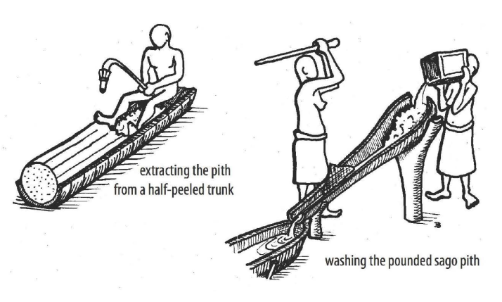

**Figure 9.7:** Extracting the starch from a sago trunk

It is probably true to say that in Oceanic-speaking communities sago is only a staple where a marshy environment causes other staples to be in short supply. Except at locations in the Admiralties, it is always a supplement to garden staples, not a replacement. Although there are communities in New Guinea which get their sago entirely from natural palm stands, Oceanic-speaking communities probably also plant palms from suckers (transplanting seedlings is rare; Rhoads 1986).

Sago palms grow very quickly, up to 1.5 m of vertical stem growth per year. They are harvested at the age of 7 to 15 years just before they flower. The palm is felled, the trunk is cut into sections. These are either split lengthways or the bark is half peeled off, and in pre-contact times the pith was extracted with tools made from hard wood, rough stone or sharpened bamboo. Commonly the crushed pith is washed and pounded, crushed or wrung (POc *poRos, vol.1 ,ch.9, §7) in an inclined trough made from a sago leaf petiole (see Figure 9.7). The starchy liquid thus extracted from the fibrous residue runs through a coconut frondnetting strainer (POc *Runut, vol.1, ch.6, §5.6; this volume, ch.12, §5.2) and is collected in leaf pans to settle. The water is decanted so that the starch can dry. The dried starch is sago flour, which is almost pure carbohydrate, for which reason it is rarely eaten alone. To preserve it, sago flour is wrapped in sago leaves or placed in clay pots and simply dampened with water from time to time. It is sometimes eaten as a porridge with additional ingredients, sometimes made into a paste which is baked into a pancake or biscuit with other ingredients, and sometimes baked in a hollow bamboo over a fire (May 1984: 54).

At least on Malaita and in the Temotu archipelago chunks of unprocessed pith are sometimes baked as an emergency food (Kwa’ioloa & Burt 2001: 191, Henderson & Hancock 1988: 34). Throughout Oceania, sago leaves, which are pinnate, not palmate, provide excellent roofing thatch. They were evidently used for this purpose by POc speakers, who called the leaves and thatch *qatop (vol.1, ch.3, §3.4). Parts of the sago palm have a variety of uses, and not just in the sago-making process itself. As well as thatching, among the Bola of New Britain the leaves are used for making screens, pillows, and canoe sails, laths of skin from the leaf midrib are made into matting which serves as a fish trap, and midribs are used to make internal partitions and heavy stiff rope (Powell 1976). The Kwara’ae feed the pith to pigs. They use the leaf spines to make needles for stitching sago thatch and darts for shooting birds, as well as for making brooms. The leaf shoot is stained and used to make decorative armbands. The frond bases used to be used as stools, and a fallen palm becomes a source of sago grubs and sago fungus, both of which are eaten (Kwa’ioloa & Burt 2001: 191).

There was apparently just one POc term for the sago palm, namely POc *Rabia. As the Fijian and Polynesian reflexes below show, early Central Pacific speakers reassigned PCP *abia, reflecting POc *Rabia, to another starch source, *Tacca leontopetaloides*, Polynesian arrowroot (§2.3.2). Kikusawa (2003: 49) argues - correctly, I think - that PPn *pia ‘Polynesian arrowroot’ is cognate with Bauan *yabia* ‘arrowroot’, and reflects loss of initial *a- from PCP *abia.[^30]

| **PMP** |  | *Rambia | ‘sago palm’ (Blust 1989) |
| --- | --- | --- | --- |
| **POc** |  | *Rabia | ‘sago, *Metroxylon* spp., mainly *Metroxylon sagu* (syn. *Metroxylon* rumphii)’ (Grace 1969: *r(a,u)bia) |
| Adm | Seimat | *api* | ‘sago’ (Sorensen 1950) |
| Adm | Titan | *api* | ‘sago’ |
| Adm | Bipi | *abi* | ‘sago’ |
| NNG | Poeng | *lamvia* | ‘sago’ |
| NNG | Malasanga | *labia* | ‘sago’ |
| NNG | Kaiwa | *labi* | ‘sago’ |
| NNG | Kairiru | *rabi* | ‘sago’ |
| PT | Muyuw | *yabiy* | ‘sago’ (F. Damon, pers. comm.) |
| PT | Kilivila | *yabia* | ‘sago’ |
| PT | Bwaidoga | *labia* | ‘sago’ |
| PT | Sariba | *labia* | ‘sago’ |
| PT | Balawaia | *labia* | ‘sago’ |
| MM | Bola | *rabia* | ‘sago’ |
| MM | Babatana | *rabia* | ‘*Nypa fruticans*’ (McClatchey et al. 2005) |
| TM | Nebao | *në-rë* | ‘sago’ |
| TM | Asumboa | *(lov)ne-te* | ‘sago’ |
| TM | Tanibili | *no-kʷo* | ‘sago’ |
| TM | Buma | *ɔtɔvɔ* | ‘sago’ |
| SV | Kwamera | *ni-epi* | ‘*Metroxylon warburgii*’ |
| **PCP** |  | *abia | ‘Polynesian arrowroot, *Tacca leontopetaloides*’ |
| Fij | Bauan | *yabia* | ‘arrowroot, starch, *Tacca leontopetaloides*’ |
| **PPn** |  | *pia | ‘Polynesian arrowroot, *Tacca leontopetaloides*’ |
| Pn | Samoan | *pia* | ‘Polynesian arrowroot, *Tacca leontopetaloides*’ (old term; Whistler 2000: 192) |
| Pn | Pileni | *pia* | ‘Polynesian arrowroot, *Tacca leontopetaloides*’ |
| Pn | Rarotongan | *pia* | ‘Polynesian arrowroot, *Tacca leontopetaloides*’ |

A glance through chapter 4 shows that where the parts of a sago palm resemble those of the coconut palm, the same terms are used for both. Thus most of the terms in §5.1 of ch.12 probably also applied to the fronds of the sago palm. The petioles of some sago species are covered in thorns, for which the POc term was *ruRi or *druRi (ch.4, 2.12).

### 5.2. *Cycas* spp., cycad, Malayan palm fern, TP *baibai*, B *namele* (Cycadaceae)

The description here is limited to *Cycas rumphii*, but, as some sources treat *Cycas scratchleyana* as a synonym of *Cycas rumphii*, I assume that the two species have almost identical features. *Cycas rumphii* grows 3-10m tall. Guppy (1906: 413), cited by Barrau (1965), considered C. rumphii to have been one of the early food sources of the Pacific Islands. Barrau mentions oral traditions about its use in New Guinea, Vanuatu, New Caledonia and Fiji. The seeds were and sometimes still are used at least as famine foods on islands throughout its Pacific distribution. Such is the strength of these oral traditions that Barrau concurs with Guppy’s view that it was at one time more than a famine food, pointing to the popularity of food made from the seeds, for example, on Guam. Other sources mention the seed pudding as something prized in places as far apart as the Ninigo Islands (Sorensen 1950) and Bellona (Christiansen 1975). Exploitation of the stem starch seems to have been much rarer in the Pacific (it is more common in parts of Asia; Thieret 1958, Whiting 1953), but it occurred at Wedau (north coast of SE Papua, Kahn 1986), in the Solomons and in New Caledonia. In the Solomons the starch was processed in much the same way as sago starch (and as with sago, the starch was harvested before fruiting; ch.9, §5.1 Parkinson 1907). In New Caledonia the stem starch was cut up and cooked (Jumelle 1907, cited by Thieret 1958). In Tonga the grated stem starch was rinsed and the starch that settled out was collected as a famine food (Whistler 1991b).

The seeds need considerable processing before they can be eaten, as they contain the toxin hydrocyanic acid. In the Ninigo Islands the otherwise poisonous fruit is submerged in salt water until the skin begins to peel off, then washed in fresh water and dried in the sun. This process removes the toxin, and the seeds are then pounded into flour, made into a pudding and baked (Sorensen 1950). The process on Guam was similar (Safford 1905, cited by Whiting 1953). On Rennell and Bellona Islands the seeds are wrapped in a fern leaf (*Microsorium scolopendria*) and soaked in water for five or more days, then pounded and baked (Henderson & Hancock 1988: 140). In Fiji the seeds were boiled until they were soft, then eaten (H. B. R. Parham 1943, cited by Thieret 1958).

*Cycas rumphii* also has a variety of other uses. Its bark sap is reported as a wood glue in Marovo and northern Malaita. In a number of places in the Bismarcks and the Solomons seeds are threaded on a string and used as a bull-roarer toy (Peekel 1984: 35, Henderson & Hancock 1988: 140, Hviding 2005: 143).

Various parts of the plant are used to cover small wounds and tropical ulcers. In the Bismarcks it is the resin of the fruit (Peekel 1984: 35, Holdsworth et al. 1982); in the Morobe Province of Papua New Guinea, the raw seeds (Barrau 1965); among Drehet speakers in Manus, it is sap obtained by cutting a notch in the bark (Beard n.d.); on Santa Ana (Solomons), the pulp of a scraped fruit. In the Reefs a bark preparation is used to treat a stomach ailment (Henderson & Hancock 1988: 140).

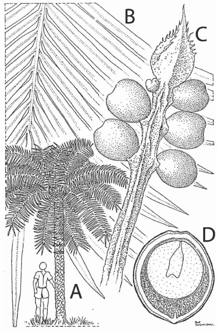

Barrau’s assertion that *Cycas rumphii* played an important role in earlier Oceanic cultures receives some support from the fact that several terms for it are reconstructable: POc *(p,pʷ)atoRu and *bai-bai(t), PEOc *mʷa(q)ele and PCP *loŋo-loŋo. The geographic distributions of these terms scarcely overlap.

The glosses of many of the terms listed below refer simply to ‘cycad’ or ‘*Cycas*’. None is identified as ‘*Cycas scratchleyana*’, and there is reasonable support for glossing all of them ‘*Cycas rumphii*’, but this is likely to be due to the fact that the two species were not distinguished until recently.

| **PMP** |  | *patuRu | ‘a cycad, *Cycas rumphii*’[^32] |
| --- | --- | --- | --- |
| **POc** |  | *(p,pʷ)atoRu | ‘a cycad, *Cycas rumphii*’ |
| Adm | Mussau | *otou* | ‘*Cycas rumphii*’ |
| Adm | Seimat | *haato* | ‘*Cycas rumphii*’ (Sorensen 1950) |
| Adm | Lou | *paro* | ‘*Cycas rumphii*’ |
| Adm | Drehet | *potop* | ‘*Cycas* palm’ |
| MM | Nakanai | *patola* | ‘cycad’ (*-a* for †*-u*) |

| **PMP** |  | *ba(y)it | ‘a cycad, *Cycas rumphii*’ (Ross 1996d) |
| --- | --- | --- | --- |
| **POc** |  | *bai-bai(t) | ‘a cycad, *Cycas rumphii*’ (Ross 1996d) |
| PT | Minaveha | *hai-hai* | ‘palm’ |
| MM | Patpatar | *be-be* | ‘cycad palm’ |
| MM | Tolai | *bai-bai* | ‘arborescent fern sp.; cycad palm’ |
| MM | Nehan | *be-be* | ‘cycad’ |
| TM | Äiwoo | *(nʷasi)poyi* | ‘*Cycas rumphii*’ |
| TM | Äiwoo | *(nʷasi)poyi* | ‘*Cycas rumphii*’ |
| SES | Longgu | *bai-bai* | ‘cycad palm’ |
| SES | Lau | *bai-bai* | ‘k.o. cycad; nut of this tied to strings and made to hum, a bull-roarer’ |
| SES | Kwara’ae | *bai-bai* | ‘*Cycas rumphii*’ |
| SES | Baelelea | *gʷae* | ‘cycad palm’ |
| SES | Kwaio | *bai-bai* | ‘k.o. cycad; nut used in whirling toy’ |
| SES | ’Are’are | *pai-pai* | ‘k.o. cycad’ |

| **PCP** |  | *loŋo-loŋo | ‘a cycad, *Cycas rumphii*’ |
| --- | --- | --- | --- |
| Fij | Bauan | *loŋo-loŋo* | ‘*Cycas rumphii*’ (Ryan 1988: 140) |
| Pn | Tongan | *loŋo-loŋo* | ‘*Cycas rumphii*’ |
| Pn | Niuean | *loŋo-loŋo* | ‘*Cycas rumphii*’ |
| Pn | West Uvean | *loŋo-loŋo* | ‘*Cycas rumphii*’ |
| Pn | Tikopia | *roŋo-roŋo* | ‘*Cycas rumphii*’ |
| Pn | Emae | *roŋo-roŋo* | ‘cycad’ |

| **PEOc** |  | *mʷa(q)ele | ‘a cycad, *Cycas rumphii*’ |
| --- | --- | --- | --- |
| SES | Ulawa | *mʷaele* | ‘*Cycas rumphii*’ (W. McClatchey, pers. comm.) |
| SES | Santa Ana | *mʷaere* | ‘*Cycas rumphii*’ |
| NCV | Mwotlap | *mʷel* | ‘*Cycas rumphii*’ |
| NCV | Mota | *mʷele* | ‘cycad’ |
| NCV | Ambae | *mʷele* | ‘*Cycas rumphii*’ |
| NCV | Kiai | *mele* | ‘*Cycas rumphii*’ |
| NCV | Raga | *mʷele* | ‘*Cycas* sp.’ (Walsh 2004) |
| NCV | Naman | *meil* | ‘*Cycas rumphii*’ |
| NCV | Neve’ei | *ni-mʷiyil* | ‘*Cycas rumphii*’ |
| NCV | Tape | *ni-mʷil* | ‘*Cycas rumphii*’ |
| NCV | Uripiv | *na-mʷel* | ‘*Cycas rumphii*’ |
| NCV | Araki | *(vi)mele* | ‘*Cycas rumphii*’ |
| NCV | Tamambo | *vu-mʷele* | ‘*Cycas rumphii*’ |
| NCV | Paamese | *maili* | ‘*Cycas rumphii*’ |
| NCV | Lewo | *(puru)mʷela* | ‘*Cycas rumphii*’ |
| NCV | Namakir | *mʷal* | ‘*Cycas rumphii*’ |
| NCV | Nguna | *na-mʷele* | ‘*Cycas rumphii*’ |
| NCV | South Efate | *na-mʷel* | ‘*Cycas rumphii*’ |
| SV | Sye | *no-mol* | ‘*Cycas rumphii*’ |
| SV | Lenakel | *nə-məl* | ‘*Cycas rumphii*’ |
| SV | Kwamera | *na-mur* | ‘*Cycas rumphii*’ |
| SV | Anejom̃ | *no-mʷoc* | ‘*Cycas rumphii*’ |
| NCal | Pije | *ŋēn* | ‘*Cycas rumphii*’ |
| NCal | Fwai | *ŋēn* | ‘*Cycas rumphii*’ |
| NCal | Nemi | *ŋēn* | ‘*Cycas rumphii*’ |
| NCal | Jawe | *ŋēn* | ‘*Cycas rumphii*’ |
| NCal | Nyelâyu | *mʷēŋ* | ‘*Cycas rumphii*’ |

## 6. Summary

This chapter has treated POc terms for staple foods, i.e. sources of starch. ‘Starchy food’ was evidently a POc category of meal ingredient and was the hyponymous sense of POc *kanaŋ ‘food’. Additional ingredients to accompany starch were probably POc *tamaji.

The main root crops grown by POc speakers were evidently *qupi, the greater yam (*Dioscorea alata*), *pʷatika, the potato yam (*Dioscorea bulbifera*), and *talo(s) or *mʷapo(q), taro (*Colocasia esculenta*) (*talo(s) was the inherited term, *mʷapo(q) a borrowing from a New Guinea mainland Papuan language). They also grew *piRaq, giant taro (*Alocasia macrorrhizos*). The importance of the greater yam and *Colocasia* taro is attested by the fact that several terms can be reconstructed for (cultivars of?) each. The lesser yam, PWOc *kamisa or *mamisa (*Dioscorea esculenta*), seems to have been domesticated by early Oceanic speakers shortly after the break-up of POc.

The swamp taro, *Cyrtosperma merkusii*, was a later introduction, reaching Melanesia probably from Micronesia. The arrival of other modern root crops postdates the European presence in Central and South America: they are the sweet potato (*Ipomoea batatas*), cassava (*Manihot esculenta*) and Xanthosoma taro.

The banana, *pudi (*Musa* cultivars), and the breadfruit, *kuluR and *baReko (*Artocarpus altilis*) were also important sources of starch for POc speakers, but the sago palm, *Rabia (*Metroxylon* species), was probably no more than a supplementary or emergency starch source.

## Notes

[^1]: *Ipomoea batatas* and *Manihot esculenta* reached Papua New Guinea sometime between European exploration in the New World and European colonisation of New Guinea, i.e. in the period 1500–1870 (Yen 1974b, Ballard et al. 2005). *Ipomoea batatas* probably arrived about 300 years ago and *Manihot esculenta* about 200 years ago (Bourke forthcoming). *Xanthosoma sagittifolium* arrived in Papua New Guinea as recently as the 19th century (Bourke 1982, Kirch 1994: 80).
[^2]: Terms associated with gardening practices are treated in vol.1, ch.6.
[^3]: Borrell (1989: 21) notes its cultivation on Kairiru Island (Schoutens).
[^4]: The agronomic and cultural relationship between the lesser and greater yam is to a degree parallel to that between taro and sweet potato. The introduced sweet potato yields better and is the more widely cultivated crop, but the taro is in many places more prestigious.
[^5]: Chowning (2001: 79, pers. comm.) reports that Sengseng and Maenge speakers on New Britain still ate wild yams in the 1950s, and Nakanai speakers remembered having done so until recently.
[^6]: The account given here differs somewhat from that in Ross (1996d).
[^7]: Cf. *ma-sauq/*ka-sauq ‘be far away’(vol.2, ch.7, §2.2.3). The history of stative verb forms in *ma- and *ka- is analysed by Evans & Ross (2001).
[^8]: The form *mami* ‘lesser yam’ also occurs in various languages of the region, but we know that this is a recent borrowing from Tok Pisin *mami*, because it shares in the *s*-loss characteristic of words which have entered Tok Pisin from the MM languages Ramoaaina and Tolai (Ross 1993).
[^9]: This is the source of the Tok Pisin term *kaukau* ‘sweet potato’, whose source was noted as unknown by Ross (1993).
[^10]: Hiri Motu, the Motu-based pidgin of Papua, received input from policemen from the Solomons, some of whom presumably spoke a SES language (Dutton 1985). John Lynch (pers. comm.) points out that Hiri Motu speakers may also have copied items from Papuan Pidgin English. Roviana is widely used as a lingua franca in the western Solomons and, like other languages of the area, has borrowings from SES languages. Roviana and Manam would also be candidates for borrowing the word ‘taro’ from, respectively, Solomons Pijin and Tok Pisin.
[^11]: Fox (1978) glosses these names as ‘sp. of taro’, and I have retained this in the glosses, but I assume that these are in fact different cultivars.
[^12]: The Tawala and Kilivila (PT) reflexes of which (*huli* and *uli*) now mean simply ‘taro’ .
[^13]: In Ross (1996d) I listed *buleha* and *bureka*. Nakanai *ula* is cited by Bender et al. (2003) from Chowning & Goodenough (n.d.).
[^14]: However, Kikusawa’s paper contains some problems. Firstly, she reconstructs POc *biRaq, denoting both Alocasia and Cyrtosperma, i.e. giant taros in general (only Wayan *via* supports the double gloss), but it is clear that the POc form was *piRaq (ch.9, §2.2.3). She offers no evidence for POc initial *b-. In a footnote she cites Bauan *via* as a regular reflex, but this reflects *piRaq, not *biRaq. Second, Kikusawa argues that PChk-Ponapeic *pʷulaka is perhaps a borrowed reflex of *biRaq, but this is unlikely, as the form was in fact *piRaq. Third, she lumps together as reflexes of POc *biRaq the NCV terms reflecting PNCV *bu(R)aga and POc *piRaq. This is unmotivated, as the forms reflecting POc *piRaq (listed under *piRaq in §2.2.3) are regular reflexes. I assume that PNCV *buaga was also a borrowed form, ultimately from PChk-Ponapeic *pʷulaka.
[^15]: Cyrtosperma is reported to have been present in New Ireland 16,500 years ago (Barton & White 1993, cited by Swadling & Hide 2005: 307). I do not know how this meshes with the much later history that concerns us here.
[^16]: The dictionary source defines this term as ‘wild arrowroot, *Amorphophallus campanulatus*’ (= *Amorphophallus paeoniifolius*). Peekel (1984: 91) gives bulaka as ‘Polynesian arrowroot, probably *Tacca leontopetaloides*’ in both Patpatar and Tolai, and I take him to be the more reliable source with regard to botanical identifications. Hay (1990: 42) notes that the leaves of the two plants are easily confused.
[^17]: The taxonomic and archaeobotanical informatiom in this section is drawn from two papers which Jean Kennedy kindly made available to me: J. Kennedy 2008 and forthcoming.
[^18]: Thus genus and section share the same name, unfortunately for the non-specialist.
[^19]: Arnaud & Horry use the old section terms Eumusa and Australimusa.
[^20]: The genus Ensete belongs, like *Musa*, to the Musaceae family. Its members have edible roots.
[^21]: Ross (1996d: 185) reconstructed a form *paRa(l,R) ‘stem, bunch (of bananas)’ supported by Wayan *baba* ‘leaf-stalk’, Tawala *halana* ‘bunch/hand of bananas’ and Bing *parar* ‘stem of/cluster (bananas, betelnut, etc); handle of axe’. The Bing term also means ‘axe handle’ and in fact reflects widely reflected POc *paRara ‘axe handle’ (ACD). Tawala *halana* is at best a borrowed reflex of this term, and perhaps not a reflex at all. Wayan *baba* is a regular reflex of POc *baRa-baRa (ch.4, §2.2).
[^22]: Kennedy & Clarke (2004) draw attention to the often overlooked but very considerable importance of breadfruit in Papua New Guinea.
[^23]: In New Caledonian languages *-n-* regularly reflects *-l-.
[^24]: Tomoip *buŋ-* is a classifier that occurs on fruit names.
[^25]: Cf. ch.13, §3.4, where a similar but not identical situation is described with regard to *Morinda citrifolia*.
[^26]: The term ‘sago palm’ is also used in North America and in New Zealand for a decorative cycad, *Cycas revoluta*, because of its vague resemblance to a *Metroxylon* palm.
[^27]: According to Barrau (1962: 142), *Metroxylon sagu* is a sterile cultivar of *Metroxylon rumphii*. Barrau (1955: 45) also lists *Metroxylon oxybracteatum* (New Guinea). Other sources do not list it.
[^28]: French (1986: 27) and McClatchey et al. (2006b) say that *Metroxylon bougainvillense* is a synonym of *M. solomonense*, but other sources view them as markedly separate species.
[^29]: McClatchey et al. (2006b) also list *Metroxylon paulcoxii* (Samoa) but say it is possibly a cultivar of *Metroxylon warburgii*.
[^30]: Samoan *pia* (and its cognates) thus do not reflect POc *piRaq ‘giant taro, *Alocasia macrorrhizos*’, as I assumed in Ross (1996d). The regular PPn reflex of POc *piRaq would be †*fia.
[^31]: A third species, *Cycas celebica*, has a discontinuous distribution - from Borneo to the Moluccas, and from Bougainville to Tonga, with an outlier in the Marianas.
[^32]: PMP *patuRu is supported by the Oceanic data here and by the following non-Oceanic cognates: Pinatubo Sambal *patogo*, Tagalog *patugo*, Hanunuo *pitugu*, Panay Bisayan *pitogo* (Madulid 2001b: 87), Kangean Madurese *pətoko*, Gorontalo *patuhu*, Buol *potugu*, Buginese *patuku* (Heyne 1950: 107).